# Hearing related phenotypes

## Aim

Create a dataset of filtered individuals using the inclusion and exclusion criteria for tinnitus phenotype to perform association analyses using the LMM.ipynb.

## Location of files

In the shared folder is the original UKBB data

```
/gpfs/gibbs/pi/dewan/data/UKBiobank/phenotype_files/pleiotropy_R01/
```

In my personal folder the filtered dataset

```
/home/dc2325/project/HI_UKBB
```

In the phenotypes folder important phenotypic files

```
/gpfs/gibbs/pi/dewan/data/UKBiobank/phenotype_files/hearing_impairment
```

## Important phenotypic files

1. `200804_UKBB_HI_genotypeqc.csv` File containing all individuals that passed QC and hearing impairment variables
2. `200804_UKBB_HI_genotypeqc_excr.csv` File with applied exclusion criteria as indicated [here](https://docs.google.com/document/d/1cpxTzElpsEkwmBDjnMBHg2wW7CL1AcG_b0_0wE_k5rQ/edit). **Note**: this file excludes individuals with otosclerosis, Meniere's and other diseases, if you need to filter those particular phenotypes use file 1 instead.
3. `200811_UKBB_Tinnitus_plan1_2_3_f4803` File with filtered phenotypes for tinnitus plan 1,2 and 3 and imputed noise variables
4. `200814_UKBB_HI_genotypeqc_excr_impvars` Database with qc'ed individuals, exclusion criteria, noise imputed vars and tinnitus phenotypes

## Subset the data using variables of interest

Using the ukbconvert software and a list of pre-specified variables

```
./ukbconv ukb42495.enc_ukb r -i/home/dc2325/project/HI_UKBB/selectvars_062520.txt -o/home/dc2325/project/HI_UKBB/ukb42495_subset062520
./ukbconv ukb42495.enc_ukb r -i/home/dc2325/project/HI_UKBB/selectvars_080420.txt -o/home/dc2325/project/HI_UKBB/ukb42495_subset080420
```

Specific to Columbia's cluster

```
./ukbconv ukb44831.enc_ukb r -i/mnt/mfs/statgen/UKBiobank/data/HI_UKBB/selectvars_101120.txt -o/mnt/mfs/statgen/UKBiobank/data/HI_UKBB/ukb44831_subset122220
```

## To submit to Columbia's cluster an interactive node

`qrsh -V -l h_vmem=80G,mem_free=60G R --save`

In R filter the dataset including only the exomed individuals and obtain the csv file (specific to Columbia's cluster)

```
setwd('/mnt/mfs/statgen/UKBiobank/data/HI_UKBB')
source("ukb44831_subset122220.r")
nrow(bd)
df.geno <- read.table("/mnt/mfs/statgen/UKBiobank/data/exome_files/ukb23155_c10_b0_v1.fam", header=FALSE, stringsAsFactors = FALSE)
names(df.geno) <-c("FID","IID","ignore1", "ignore2", "ignore3", "ignore4")
nrow(df.geno)
head(bd[,1, drop=FALSE])
names(bd)[1] <- "IID"
head(bd[,1, drop=FALSE])
df.gen.phen <-merge(df.geno, bd, by="IID", all=FALSE)
nrow(df.gen.phen)
write.csv(df.gen.phen,'122820_UKBB_HI_exomes.csv', row.names = FALSE)
```

## Genotypic/exome data

### Subsetting individuals with genotypic data

```python
#Load libraries
library(plyr)
library(tidyverse)
library(pander)
library(ggpubr)
library(rapportools)
library(ggplot2)
#Get working directory
getwd()
```

'/gpfs/gibbs/pi/dewan/data/UKBiobank/phenotype_files/hearing_impairment'

```python
#Set working directory
setwd('/home/dc2325/project/HI_UKBB/')
```

```python
# Clean workspace
rm(list=ls())
```

```python
# Run script to import data to R
#source("ukb42495_updatedJune2020/ukb42495_subset080420.r") #older data
source("ukb44831_subset122220.r")
nrow(bd)
```

502491

## List of individuals with qc'ed genotypic files: make sure you choose correct file to work with

### Only white British old file 02-07-20

```python
df.geno <- read.table("/gpfs/gibbs/pi/dewan/data/UKBiobank/genotype_files/pleiotropy_geneticfiles/UKB_Caucasians_phenotypeindepqc120319_updated020720removedwithdrawnindiv.fam", header= FALSE, stringsAsFactors = FALSE)
```

### Only white British new file 08-20-20

```python
df.geno <- read.table("/gpfs/gibbs/pi/dewan/data/UKBiobank/genotype_files/pleiotropy_geneticfiles/UKB_Caucasians_phenotypeindepqc120319_updated082020removedwithdrawnindiv.fam", header= FALSE, stringsAsFactors = FALSE)
```

### Expanded white

```python
df.geno <- read.table("/gpfs/gibbs/pi/dewan/data/UKBiobank/genotype_files/pleiotropy_geneticfiles/UKB_expandedwhite_qcgenotypefiles/UKB_expandedwhiteonly_phenotypeindepqc_410905indiv_528206snps_102720.fam", header= FALSE, stringsAsFactors = FALSE)
```

```python
names(df.geno) <-c("FID","IID","ignore1", "ignore2", "ignore3", "ignore4")
nrow(df.geno)
```

### Get the fam file for exome data after PCA analysis

This only needs to be done once

```python
exome_original <- read.table("/gpfs/gibbs/pi/dewan/data/UKBiobank/genotype_files/ukb28374_exomedata/exome_data_OCT2020/ukb23155_s200631.fam", header= FALSE, stringsAsFactors = FALSE)
names(exome_original) <-c("FID","IID","ignore1", "ignore2", "ignore3", "ignore4")
nrow(exome_original)
exome_PCA <- read.table("/gpfs/gibbs/pi/dewan/data/UKBiobank/results/pca_exomes/exome_IID_188448_outliers_removed.txt", header= FALSE, stringsAsFactors = FALSE)
names(exome_PCA) <-c("FID","IID")
nrow(exome_PCA)
exome_PCA<-exome_PCA[,1]
final_exome  <- exome_original %>%
    filter(IID%in%exome_PCA)
nrow(final_exome)
setwd('/gpfs/gibbs/pi/dewan/data/UKBiobank/genotype_files/ukb28374_exomedata/exome_data_OCT2020/')
write.table(final_exome, 'ukb23155_s200631_188448ind.fam', quote = FALSE, row.names = FALSE)
```

### Exome data

```python
df.geno <- read.table("/gpfs/gibbs/pi/dewan/data/UKBiobank/genotype_files/ukb28374_exomedata/exome_data_OCT2020/ukb23155_s200631_188448ind.fam", header= TRUE, stringsAsFactors = FALSE)
nrow(df.geno)
```

188448

```python
head(bd[,1, drop=FALSE])
```

A data.frame: 6 × 1

|  | f.eid <int> |
| --- | --- |
| 1 | 1000019 |
| 2 | 1000022 |
| 3 | 1000035 |
| 4 | 1000046 |
| 5 | 1000054 |
| 6 | 1000063 |

```python
# Assign individual ID column to bd f.eid
names(bd)[1] <- "IID"
head(bd[,1, drop=FALSE])
```

A data.frame: 6 × 1

|  | IID <int> |
| --- | --- |
| 1 | 1000019 |
| 2 | 1000022 |
| 3 | 1000035 |
| 4 | 1000046 |
| 5 | 1000054 |
| 6 | 1000063 |

```python
# Merge the two data frames
df.gen.phen <-merge(df.geno, bd, by="IID", all=FALSE)
nrow(df.gen.phen)
```

188447

```python
#Individual that is missing in the exome data
withdrawn_iid <- setdiff(df.geno[,'IID'],bd[,'IID'])
withdrawn_iid
```

2799536

## Save as csv files

```python
write.csv(df.gen.phen,'200804_UKBB_HI_genotypeqc.csv', row.names = FALSE)
```

### Save file for only-British without applying exclusion criteria

```python
write.csv(df.gen.phen,'010521_UKBB_HI_genotypeqc_onlybritish_366734indiv.csv', row.names = FALSE)
```

### Save file for expanded white without applying exclusion criteria

```python
write.csv(df.gen.phen,'010521_UKBB_HI_genotypeqc_expandedwhite_410894indiv.csv', row.names = FALSE)
```

### Save file for exome data without applying exclusion criteria

```python
write.csv(df.gen.phen,'122820_UKBB_HI_exomes.csv', row.names = FALSE)
```

```python
write.csv(df.gen.phen,'010621_UKBB_HI_exomes_188447ind.csv', row.names = FALSE)
```

# Tinnitus phenotype (binary)

NOTE: FIXME re-do exclusion criteria for bigger database

## Exclusion criteria based on ICD10, ICD9 codes and self-report

Apply the exclusion criteria defined by the group to remove unwanted individuals. This takes into account ICD10 codes, ICD9 codes and f.20002 (self-report). Please find a list of removed codes [here](https://docs.google.com/spreadsheets/d/12L7Cx4Ov8FppGVmG0DxL9uG-lVRHM5QJSea0nORyirQ/edit#gid=0). A total 12397 individuals were excluded in this step.

```python
# To get a list of removed individuals. Make sure the list with the strings each line has \bstring\b so it can be recognized by -w
cd /home/dc2325/project/HI_UKBB
```

```python
grep -w -f 200713_ICDcodes_exclusion.txt 200804_UKBB_HI_genotypeqc.csv > 200804_UKBB_excluded_individuals.csv
cat 200804_UKBB_excluded_individuals.csv | wc -l #12397 excluded
```

```python
# To get the clean db with the included individuals
grep -wv -f 200713_ICDcodes_exclusion.txt 200804_UKBB_HI_genotypeqc.csv > 200804_UKBB_HI_genotypeqc_excr.csv
cat 200804_UKBB_HI_genotypeqc_excr.csv | wc -l #354347 retained
# To obtain the duplicate lines (if they exist)
#comm -12 <(sort 200713_UKBB_genotypeqc_tinnitus_excr.csv) <(sort 200713_UKBB_excluded_individuals.csv)
```

```python
library(tidyverse)
setwd('/home/dc2325/project/HI_UKBB/')
# Clean workspace
rm(list=ls())
```

### Load csv data for white-British

```python
hi_geno <- read.csv("010521_UKBB_HI_genotypeqc_onlybritish_366734indiv.csv")
nrow(hi_geno)
```

### Load csv data for expanded white

```python
hi_geno <- read.csv("010521_UKBB_HI_genotypeqc_expandedwhite_410894indiv.csv")
nrow(hi_geno)
```

410894

### Load csv data for exomes

```python
hi_geno <- read.csv("122820_UKBB_HI_exomes.csv")
```

### Load csv exomes after removing PCA outliers

```python
hi_geno <- read.csv("010621_UKBB_HI_exomes_188447ind.csv")
```

## Specify the codes to be filtered

```python
a <- c('H800','H801','H802','H808','H809', 'H810', 'H830','H90','H900','H901', 'H902',
 'H903', 'H904', 'H905', 'H906', 'H907', 'H908', 'H933', 'H940','H65','H652','H653','H654','H659','H66',
 'H661', 'H662', 'H663', 'H664', 'H669', 'G00', 'G01', 'G02', 'G020', 'G021', 'G03', 'G030', 'G031',
 'G032', 'G038', 'G039', 'G04', 'G040', 'G042', 'G048', 'G049', 'G05', 'G050', 'G051', 'G052', 'G058','G06',
 'G060', 'G061', 'G062', 'G07', 'G08', 'G09', 'G510', 'G511', 'G512', 'G513', 'G514','G518','G519', 'S02',
 'S020', 'S0200', 'S0201', 'S021', 'S0210', 'S0211', 'S024', 'S0240',
 'S0241', 'S026', 'S0260', 'S0261', 'S027', 'S0270', 'S0271', 'S028', 'S0280', 'S0281','S029',
 'S0290', 'S0291', 'S030', 'S034','S04', 'S045', 'S046', 'S049', 'S06', 'S060','S0600',
 'S0601', 'S061', 'S0610', 'S0611', 'S062', 'S0620', 'S0621', 'S063', 'S0630', 'S0631',
 'S064', 'S0640', 'S0641', 'S065', 'S0650', 'S0651', 'S066', 'S0660', 'S0661', 'S067',
 'S0670', 'S0671','S068','S0680', 'S0681', 'S069', 'S0690', 'S0691', 'S07', 'S070', 'S071',
 'S078', 'S079', 'S08', 'S080', 'S081', 'S088', 'S089', 'S09', 'B020', 'B021', 'B022', 'B023',
 'B027', 'B028', 'H70', 'H701', 'H702', 'H708', 'H709')

b <- c('389','387', '3870', '3871', '3872', '3878', '3879', '3860', '3863', '389', '3890', '3891',
'3892', '3897', '3898', '3899','3885', '3813', '3814', '3816', '3819', '382', '3821', '3822', '3823',
 '3824', '3829', '320', '3200', '3201', '3202', '3203', '3204', '3205', '3207', '3208', '3209', '321',
'3210', '3211', '3212', '3213', '3214', '3215', '3216', '3217', '3218', '322', '3220', '3221', '3222',
 '3229', '323', '3230',  '3231', '3232', '3233', '3234', '3235',  '3236','3237', '3238', '3239', '324',
 '3240', '3241', '3249', '325','326', '3510','3511', '3518', '3519', '800', '8000', '8001', '8002',
 '8003',  '801', '8010', '8022', '8023', '8024', '8028', '8029', '803', '8030', '8031', '8032', '8033',
'804', '8040', '8041', '8042', '8043', '830', '8300', '8301', '8481', '9514', '9515', '9519', '854',
 '8540', '8541', '850', '8509', '851', '8510', '8511', '852', '8520', '8521', '853', '8530', '8531',
'854',  '8540', '8541', '872', '8720','8721', '8726', '8727', '8728', '8729', '873', '8730',
'8731', '9050', '925', '9259', '530', '531', '532', '537', '538', '539', '383', '3831', '3832',
'3833', '3838', '3839')

c <- c('1420', '1421', '1499', '1249','1247','1246', '1245', '1250', '1240', '1626', '1627',
 '1491')
```

```python
to_exclude <- hi_geno %>%
  mutate(exclude = apply(select(hi_geno,starts_with("f.41270")),1,function(x) any(x %in% a))
  | apply(select(hi_geno,starts_with("f.41271")),1,function(x) any(x %in% b)) |
   apply(select(hi_geno,starts_with("f.20002")),1,function(x) any(x %in% c))
  ) %>%
  filter(exclude=="TRUE")
nrow(to_exclude)
```

6226

```python
to_keep <- hi_geno %>%
  mutate(exclude = apply(select(hi_geno,starts_with("f.41270")),1,function(x) any(x %in% a))
  | apply(select(hi_geno,starts_with("f.41271")),1,function(x) any(x %in% b)) |
   apply(select(hi_geno,starts_with("f.20002")),1,function(x) any(x %in% c))
  ) %>%
  filter(exclude=="FALSE")
nrow(to_keep)
```

182221

## Save to csv files after exclusion criteria is applied

### Only British

```python
write.csv(to_keep,file='010521_UKBB_HI_genotypeqc_onlybritish_354345indiv_excr.csv',row.names=FALSE) #12389 excluded and 354345 retained
```

### Expanded white

```python
write.csv(to_keep,file='010521_UKBB_HI_genotypeqc_expandedwhite_396974indiv_excr.csv',row.names=FALSE) #13920 excluded and 396974 retained
```

### Exome data

```python
write.csv(to_keep,file='010621_UKBB_HI_exomes_182221ind_excr.csv',row.names=FALSE) #6226 excluded and 182221 retained
```

## Import clean data

### Only white-British individuals

```python
df_clean <- read.csv(file = '200804_UKBB_HI_genotypeqc_excr.csv', header=TRUE)
```

### Including all white individuals

```python
df_clean <- read.csv(file = '120120_UKBB_HI_expandedwhite_genotypeqc_excr.csv', header=TRUE)
```

### Including only individuals with exome data

```python
setwd('/gpfs/gibbs/pi/dewan/data/UKBiobank/phenotype_files/hearing_impairment')
df_clean <- read.csv(file = '010621_UKBB_HI_exomes_182221ind_excr.csv', header=TRUE)
```

**Analysis plan:**

1. Individuals who currently have tinnitus (all three yes categories) vs no never only controlling for sex, age, noisy workplace and loud music frequency (“crude”) (No tinnitus vs anytype of tinnitus). For this analysis the missing data of the noise variables was imputed using the median for cases and controls separately
2. Individuals in the two top YES categories vs NO never (‘No’ tinnitus vs ‘Yes, now all of the time’ and ‘Yes, now most of the time’)
3. Individuals that say yes in the top 3 categories vs No never (Remove category ‘yes, but not now, but have it in the past’)

## Data summary and recode

```python
dim(df_clean)
```

1. 182221

2. 2262

### Recode genetic sex f.22001

```python
table(df_clean$f.22001)
```

```
Female   Male
100626  81436
```

```python
compare_sex <- df_clean %>%
      mutate(sex_final = case_when(
       f.31.0.0 == f.22001.0.0 & f.22001.0.0 == "Female" ~ "0",
       f.31.0.0 == f.22001.0.0 & f.22001.0.0 == "Male" ~ "1",
       TRUE ~ '3')) %>%
    select(IID, f.31.0.0, f.22001.0.0, sex_final) %>%
    filter(sex_final==3)
head(compare_sex, 10)
dim(compare_sex)
```

A data.frame: 10 × 4

|  | IID <int> | f.31.0.0 <fct> | f.22001.0.0 <fct> | sex_final <chr> |
| --- | --- | --- | --- | --- |
| 1 | 1045692 | Female | NA | 3 |
| 2 | 1048098 | Male | NA | 3 |
| 3 | 1068847 | Male | Female | 3 |
| 4 | 1096848 | Male | NA | 3 |
| 5 | 1101132 | Male | Female | 3 |
| 6 | 1121872 | Female | NA | 3 |
| 7 | 1161768 | Male | Female | 3 |
| 8 | 1184630 | Female | NA | 3 |
| 9 | 1236324 | Male | Female | 3 |
| 10 | 1250098 | Female | NA | 3 |

1. 215

2. 4

## Remove sex inconsistent individuals

```python
remove_sex <- compare_sex %>%
    select(IID)
head(remove_sex)
dim(remove_sex)
```

A data.frame: 6 × 1

|  | IID <int> |
| --- | --- |
| 1 | 1045692 |
| 2 | 1048098 |
| 3 | 1068847 |
| 4 | 1096848 |
| 5 | 1101132 |
| 6 | 1121872 |

1. 215

2. 1

```python
df_clean <-  df_clean[!df_clean$IID %in% remove_sex$IID,]
dim(df_clean)
```

1. 182006

2. 2262

```python
df_clean$sex <- revalue(df_clean$f.22001.0.0, c("Male" = '0', 'Female'='1' ))
table(df_clean$sex)
dim(df_clean)
```

```
     1      0
100570  81436
```

1. 182006

2. 2263

```python
length(which(is.na(df_clean$sex)))
```

0

## Filter out inconsistent cases

Recode 4 instances of field f.4803 with 0,1, and 9

- Yes, now most or all of the time : 1
- Yes, now a lot of the time: 1
- Yes, now some of the time: 1
- Yes, but not now, but have in the past : 1
- No, never: 0
- Do not know: 9 Prefer not to answer: NA

```python
# Recode function:
recode<-function(df,column_name){
  new_names<-c()
  for (i in column_name){
    new_column_name<-paste0(i,"_recode")
    new_names<-c(new_names,new_column_name)
    df[,new_column_name] <- revalue(df[,i], c("No, never"= 0,
                                            "Yes, but not now, but have in the past"= 1,
                                            "Yes, now some of the time"= 1,
                                            "Yes, now a lot of the time"= 1,
                                            "Yes, now most or all of the time"= 1,
                                            "Prefer not to answer"= NA,
                                            "Do not know"= 9 ))
  }
  return (list(df=df,new_column_names=new_names))
}

# columns needs to be recoded:
column_name<-c("f.4803.0.0","f.4803.1.0","f.4803.2.0","f.4803.3.0")

# get a new data.frame with recoded columns added:
df_clean<-recode(df=df_clean,column_name)$df

# get names of recoded columns:
new_column_names<-recode(df=df_clean,column_name)$new_column_names

# show recode summary:
for (i in new_column_names)
{cat(i,"summary:");print(table(df_clean[,i]));cat("\n")}
```

```
f.4803.0.0_recode summary:
    9     0     1
 1324 52615 20772

f.4803.1.0_recode summary:
   9    0    1
 119 6529 2777

f.4803.2.0_recode summary:
    9     0     1
  274 16061  7635

f.4803.3.0_recode summary:
  9   0   1
 11 634 286
```

```python
dim(df_clean)
```

1. 182006

2. 2267

### 1. Get patterns for all possible answers

```python
# Extract subset of data only with the recode columns of tinnitus
data_sub <- df_clean %>%
  select("IID",all_of(new_column_names))

# Function to extract all the available answers for 4 visits
# and put them in one string as "0000", "111", "991", etc

f2<-function(x){
  visit<-''
  for (i in 2:5){ # do not take the first column (i.e. IID)
    if (!is.na(x[i]))
    {visit<-paste0(visit,x[i])}
  }
  if(is.null(visit)){visit=NA}
  else{visit=visit}
  return (visit)
}

# Apply the above function and remove NAs
data_sub$visit<-apply(data_sub, 1, f2)

names(table(data_sub$visit))
```

1. ''

2. '0'

3. '00'

4. '000'

5. '0000'

6. '0001'

7. '001'

8. '0010'

9. '0011'

10. '009'

11. '01'

12. '010'

13. '0100'

14. '011'

15. '0111'

16. '019'

17. '09'

18. '090'

19. '091'

20. '099'

21. '1'

22. '10'

23. '100'

24. '1000'

25. '101'

26. '1010'

27. '1011'

28. '11'

29. '110'

30. '1100'

31. '1101'

32. '111'

33. '1110'

34. '1111'

35. '119'

36. '19'

37. '190'

38. '191'

39. '1919'

40. '199'

41. '9'

42. '90'

43. '900'

44. '901'

45. '909'

46. '91'

47. '911'

48. '99'

49. '990'

50. '991'

```python
all_pattern<-unique(data_sub$visit)

cat("There are",length(all_pattern),"different combinations of answers.\n")
```

```
There are 50 different combinations of answers.
```

```python
cat("Those with 4 numbers has answer for all 4 visits. e.g. '0000': No, No, No, No.\n")
```

```
Those with 4 numbers has answer for all 4 visits. e.g. '0000': No, No, No, No.
```

```python
cat("Those with 3 numbers has answer for 3 answers out of 4 visits. e.g. '001': No, No, Yes. \n")
```

```
Those with 3 numbers has answer for 3 answers out of 4 visits. e.g. '001': No, No, Yes.
```

```python
cat("Those with 2 numbers has answer for 2 answers out of 4 visits. e.g. '90': Do not know, No. \n")
```

```
Those with 2 numbers has answer for 2 answers out of 4 visits. e.g. '90': Do not know, No.
```

```python
cat("The first one, i.e. '' is for NAs.\n")
```

```
The first one, i.e. '' is for NAs.
```

```python
table(data_sub$visit)
```

```
          0    00   000  0000  0001   001  0010  0011   009    01   010  0100
89749 53944  7832  1050    44     3    97     2     3     7  1249    54     2
  011  0111   019    09   090   091   099     1    10   100  1000   101  1010
  103     6     3    90     6     2     2 22170   753    77     5    29     1
 1011    11   110  1100  1101   111  1110  1111   119    19   190   191  1919
    1  2754    45     1     1   321     2     8     1    53     2     5     1
  199     9    90   900   901   909    91   911    99   990   991
    1  1352    65     8     3     3    68     7    18     2     1
```

### 2. Extract consistent cases

```python
all_no<-all_pattern[which(grepl("0",all_pattern) & !grepl("9",all_pattern) & !grepl("1",all_pattern))]
all_yes<-all_pattern[which(!grepl("0",all_pattern) & !grepl("9",all_pattern) & grepl("1",all_pattern))]
all_do_not_know<-all_pattern[which(!grepl("0",all_pattern) & grepl("9",all_pattern) & !grepl("1",all_pattern))]
table(data_sub[data_sub$visit%in%union(union(all_no,all_yes),all_do_not_know),"visit"])
```

```
    0    00   000  0000     1    11   111  1111     9    99
53944  7832  1050    44 22170  2754   321     8  1352    18
```

```python
consistent_1<-c(all_no,all_yes,all_do_not_know)

# might be inconsistent cases:
do_not_know_no<-all_pattern[which(grepl("0",all_pattern) & grepl("9",all_pattern) & !grepl("1",all_pattern))]
table(data_sub[data_sub$visit%in%do_not_know_no,"visit"])
```

```
009  09 090 099  90 900 909 990
  7  90   6   2  65   8   3   2
```

```python
do_not_know_yes<-all_pattern[which(!grepl("0",all_pattern) & grepl("9",all_pattern) & grepl("1",all_pattern))]
table(data_sub[data_sub$visit%in%do_not_know_yes,"visit"])
```

```
 119   19  191 1919  199   91  911  991
   1   53    5    1    1   68    7    1
```

```python
yes_no<-all_pattern[which(grepl("0",all_pattern) & !grepl("9",all_pattern) & grepl("1",all_pattern))]
table(data_sub[data_sub$visit%in%yes_no,"visit"])
```

```
0001  001 0010 0011   01  010 0100  011 0111   10  100 1000  101 1010 1011  110
   3   97    2    3 1249   54    2  103    6  753   77    5   29    1    1   45
1100 1101 1110
   1    1    2
```

```python
with_all_three<-all_pattern[which(grepl("0",all_pattern) & grepl("9",all_pattern) & grepl("1",all_pattern))]
table(data_sub[data_sub$visit%in%with_all_three,"visit"])
```

```
019 091 190 901
  3   2   2   3
```

```python
might_inconsistent<-c(do_not_know_no,do_not_know_yes,yes_no,with_all_three)
```

### 3. Remove inconsistent cases and NAs

```python
# get all the inconsistent cases:
exceptions<-c("91","911","991","0001","001","0011","01","011","0111", "091", "901", "9011")
inconsistent<-setdiff(might_inconsistent,exceptions)

cat("There are",length(which(is.empty(data_sub$visit))),"NAs, removed")
```

```
There are 89749 NAs, removed
```

```python
cat("There are",length(which(data_sub$visit%in%inconsistent)),"inconsistent cases, removed")
```

```
There are 1222 inconsistent cases, removed
```

```python
# removed those NAs and inconsistent cases:
IID_cleaned<-data_sub %>%
  filter(!is.empty(visit)) %>%
  filter((!visit%in%inconsistent)) %>%
  select(IID)

dim(IID_cleaned)
```

1. 91035

2. 1

```python
IID_cleaned<-IID_cleaned[,1]
cat("After removing all the NAs and inconsistent cases, there are",length(IID_cleaned),"cases left")
```

```
After removing all the NAs and inconsistent cases, there are 91035 cases left
```

```python
# get the dataset after cleansing:
data_cleaned<-df_clean %>%
  filter(IID%in%IID_cleaned)

dim(data_cleaned)
```

1. 91035

2. 2267

# Filter tinnitus for different analyses

Recode 4 instances of field f.4803 with 4,3,2,1,0, and 9

- Yes, now most or all of the time : 4
- Yes, now a lot of the time: 3
- Yes, now some of the time: 2
- Yes, but not now, but have in the past : 1
- No, never: 0
- Do not know: 9
- Prefer not to answer: NA

### 1. Recode f.4803

```python
# Recode function:
recode<-function(df,column_name){
  new_names<-c()
  for (i in column_name){
    new_column_name<-paste0(i,"_recode")
    new_names<-c(new_names,new_column_name)
    df[,new_column_name] <- revalue(df[,i], c("No, never"= 0,
                                            "Yes, but not now, but have in the past"= 1,
                                            "Yes, now some of the time"= 2,
                                            "Yes, now a lot of the time"= 3,
                                            "Yes, now most or all of the time"= 4,
                                            "Prefer not to answer"= NA,
                                            "Do not know"= 9 ))
  }
  return (list(df=df,new_column_names=new_names))
}

# columns needs to be recoded:
column_name<-c("f.4803.0.0","f.4803.1.0","f.4803.2.0","f.4803.3.0")

# get a new data.frame with recoded columns added:
df_recode<-recode(df=data_cleaned,column_name)$df

# get names of recoded columns:
new_column_names<-recode(df=data_cleaned,column_name)$new_column_names

# show recode summary:
for (i in new_column_names)
{cat(i,"summary:");print(table(df_recode[,i]));cat("\n")}
```

```
f.4803.0.0_recode summary:
    9     0     1     3     4     2
 1265 52482  7618  1825  4484  6112

f.4803.1.0_recode summary:
   9    0    1    3    4    2
  67 6305  697  269  732  778

f.4803.2.0_recode summary:
    9     0     1     3     4     2
  137 15175  2276   807  2063  2400

f.4803.3.0_recode summary:
  9   0   1   3   4   2
  1 544  71  29  83  96
```

### 2. Get patterns for all visits

```python
# Extract subset of data only with the recode columns of tinnitus
data_sub <- df_recode %>%
  select("IID",all_of(new_column_names))

# Function to extract all the available answers for 4 visits
# and put them in one string as "0000", "111", "991", etc

f2<-function(x){
  visit<-''
  for (i in 2:5){ # do not take the first column (i.e. IID)
    if (!is.na(x[i]))
    {visit<-paste0(visit,x[i])}
  }
  if(is.null(visit)){visit=NA}
  else{visit=visit}
  return (visit)
}

# Apply the above function and remove NAs
data_sub$visit<-apply(data_sub, 1, f2)

names(table(data_sub$visit))
```

1. '0'

2. '00'

3. '000'

4. '0000'

5. '0001'

6. '0002'

7. '001'

8. '002'

9. '0021'

10. '0022'

11. '003'

12. '0033'

13. '004'

14. '01'

15. '011'

16. '0111'

17. '012'

18. '013'

19. '014'

20. '02'

21. '021'

22. '022'

23. '0223'

24. '023'

25. '024'

26. '03'

27. '031'

28. '032'

29. '033'

30. '034'

31. '0344'

32. '04'

33. '042'

34. '043'

35. '044'

36. '091'

37. '092'

38. '1'

39. '11'

40. '111'

41. '1111'

42. '112'

43. '113'

44. '12'

45. '121'

46. '122'

47. '123'

48. '124'

49. '13'

50. '133'

51. '134'

52. '14'

53. '142'

54. '143'

55. '144'

56. '2'

57. '21'

58. '211'

59. '212'

60. '22'

61. '221'

62. '222'

63. '2222'

64. '223'

65. '23'

66. '231'

67. '232'

68. '2322'

69. '233'

70. '234'

71. '24'

72. '242'

73. '243'

74. '244'

75. '3'

76. '31'

77. '311'

78. '312'

79. '313'

80. '32'

81. '321'

82. '322'

83. '323'

84. '324'

85. '33'

86. '3311'

87. '332'

88. '333'

89. '334'

90. '34'

91. '342'

92. '343'

93. '344'

94. '4'

95. '41'

96. '413'

97. '42'

98. '421'

99. '422'

100. '423'

101. '43'

102. '432'

103. '433'

104. '434'

105. '44'

106. '441'

107. '442'

108. '443'

109. '444'

110. '4444'

111. '9'

112. '902'

113. '903'

114. '904'

115. '91'

116. '911'

117. '912'

118. '92'

119. '921'

120. '924'

121. '93'

122. '932'

123. '933'

124. '934'

125. '94'

126. '99'

127. '991'

```python
all_pattern<-unique(data_sub$visit)

cat("There are",length(all_pattern),"different combinations of answers.\n")
```

```
There are 127 different combinations of answers.
```

```python
table(data_sub$visit)
```

```
    0    00   000  0000  0001  0002   001   002  0021  0022   003  0033   004
53944  7832  1050    44     2     1    39    44     1     1     5     1     9
   01   011  0111   012   013   014    02   021   022  0223   023   024    03
  488    17     3    11     3     1   453     9    23     1     2     4   117
  031   032   033   034  0344    04   042   043   044   091   092     1    11
    3     2     3     2     2   191     6     2    15     1     1  8298   474
  111  1111   112   113    12   121   122   123   124    13   133   134    14
   35     1     9     3   211    14    18     4     2    28     1     1    59
  142   143   144     2    21   211   212    22   221   222  2222   223    23
    4     2     5  6868   184     7     9   421     5    19     1     4   103
  231   232  2322   233   234    24   242   243   244     3    31   311   312
    1     5     1     3     3   131     2     3    12  1975    37     2     1
  313    32   321   322   323   324    33  3311   332   333   334    34   342
    1   110     1     6     7     5    87     1     3     2     8   118     2
  343   344     4    41   413    42   421   422   423    43   432   433   434
    2    14  5029    25     1    62     1     1     1    90     3     2    10
   44   441   442   443   444  4444     9   902   903   904    91   911   912
  614     1     4     5    67     4  1352     1     1     1    27     1     1
   92   921   924    93   932   933   934    94    99   991
   32     1     1     3     1     1     1     6    18     1
```

# Analysis plan 1

## 1. Filter out the 9

```python
# define cases and control for specific analysis:
all_answers<-c("0","1","2","3","4","9")
control<-c('0')
cases<-c("1","2","3","4")

f3<-function(x){
  get_rid_of<-setdiff(all_answers,union(cases,control))

  for (i in get_rid_of){
  if (grepl(i,x[which(colnames(data_sub)=="visit")])){
    removed=TRUE
    break
  }
  else{removed=FALSE}
  }
  return (removed)
}
data_p1<-data_sub
data_p1$removed<-apply(data_p1, 1, f3)

# filter
data_p1<-data_p1 %>%
  filter(removed==FALSE)
head(data_p1,40)
```

A data.frame: 40 × 7

|  | IID <int> | f.4803.0.0_recode <fct> | f.4803.1.0_recode <fct> | f.4803.2.0_recode <fct> | f.4803.3.0_recode <fct> | visit <chr> | removed <lgl> |
| --- | --- | --- | --- | --- | --- | --- | --- |
| 1 | 1000078 | NA | 0 | 0 | NA | 00 | FALSE |
| 2 | 1000081 | 0 | NA | NA | NA | 0 | FALSE |
| 3 | 1000236 | 0 | NA | 0 | NA | 00 | FALSE |
| 4 | 1000255 | 0 | NA | 0 | NA | 00 | FALSE |
| 5 | 1000331 | 1 | NA | NA | NA | 1 | FALSE |
| 6 | 1000340 | 0 | NA | NA | NA | 0 | FALSE |
| 7 | 1000357 | 1 | NA | NA | NA | 1 | FALSE |
| 8 | 1000421 | 0 | NA | NA | NA | 0 | FALSE |
| 9 | 1000439 | 2 | NA | NA | NA | 2 | FALSE |
| 10 | 1000443 | NA | NA | 1 | NA | 1 | FALSE |
| 11 | 1000494 | 1 | NA | NA | NA | 1 | FALSE |
| 12 | 1000516 | 0 | NA | NA | NA | 0 | FALSE |
| 13 | 1000530 | 0 | NA | NA | NA | 0 | FALSE |
| 14 | 1000609 | NA | 0 | NA | NA | 0 | FALSE |
| 15 | 1000611 | 0 | NA | NA | NA | 0 | FALSE |
| 16 | 1000625 | 1 | NA | NA | NA | 1 | FALSE |
| 17 | 1000642 | 0 | NA | NA | NA | 0 | FALSE |
| 18 | 1000683 | 0 | 0 | NA | NA | 00 | FALSE |
| 19 | 1000713 | 3 | NA | 1 | NA | 31 | FALSE |
| 20 | 1000875 | 1 | NA | NA | NA | 1 | FALSE |
| 21 | 1000893 | 0 | NA | NA | NA | 0 | FALSE |
| 22 | 1000992 | NA | NA | 1 | NA | 1 | FALSE |
| 23 | 1001080 | 2 | NA | NA | NA | 2 | FALSE |
| 24 | 1001123 | 4 | NA | NA | NA | 4 | FALSE |
| 25 | 1001140 | 0 | NA | NA | NA | 0 | FALSE |
| 26 | 1001179 | 1 | NA | NA | NA | 1 | FALSE |
| 27 | 1001207 | 0 | NA | NA | NA | 0 | FALSE |
| 28 | 1001254 | NA | NA | 2 | NA | 2 | FALSE |
| 29 | 1001316 | 0 | NA | 0 | NA | 00 | FALSE |
| 30 | 1001349 | 0 | NA | NA | NA | 0 | FALSE |
| 31 | 1001351 | 0 | NA | NA | NA | 0 | FALSE |
| 32 | 1001373 | 2 | NA | NA | NA | 2 | FALSE |
| 33 | 1001384 | 2 | NA | NA | NA | 2 | FALSE |
| 34 | 1001395 | NA | 2 | NA | NA | 2 | FALSE |
| 35 | 1001603 | 0 | NA | NA | NA | 0 | FALSE |
| 36 | 1001636 | 2 | NA | NA | NA | 2 | FALSE |
| 37 | 1001691 | NA | 0 | 0 | NA | 00 | FALSE |
| 38 | 1001717 | NA | 0 | NA | NA | 0 | FALSE |
| 39 | 1001758 | NA | 0 | NA | NA | 0 | FALSE |
| 40 | 1001775 | 0 | NA | NA | NA | 0 | FALSE |

```python
# change all "1", "2" "3" and "4" into "1"
data_p1$visit<-gsub("1|2|3|4","1",data_p1$visit)
table(data_p1$visit)
```

```
    0    00   000  0000  0001   001  0011    01   011  0111     1    11   111
53944  7832  1050    44     3    97     3  1249   103     6 22170  2754   321
 1111
    8
```

```python
names(table(data_p1$visit))
```

1. '0'

2. '00'

3. '000'

4. '0000'

5. '0001'

6. '001'

7. '0011'

8. '01'

9. '011'

10. '0111'

11. '1'

12. '11'

13. '111'

14. '1111'

```python
# get the dataset for plan 1:
IID_plan1<-data_p1$IID
data_p1<-data_cleaned[which(data_cleaned$IID%in%IID_plan1),]
dim(data_p1)
```

1. 89584

2. 2267

```python
head(data_p1[,column_name],40)
```

A data.frame: 40 × 4

|  | f.4803.0.0 <fct> | f.4803.1.0 <fct> | f.4803.2.0 <fct> | f.4803.3.0 <fct> |
| --- | --- | --- | --- | --- |
| 1 | NA | No, never | No, never | NA |
| 2 | No, never | NA | NA | NA |
| 3 | No, never | NA | No, never | NA |
| 4 | No, never | NA | No, never | NA |
| 5 | Yes, but not now, but have in the past | NA | NA | NA |
| 6 | No, never | NA | NA | NA |
| 7 | Yes, but not now, but have in the past | NA | NA | NA |
| 8 | No, never | NA | NA | NA |
| 9 | Yes, now some of the time | NA | NA | NA |
| 10 | NA | NA | Yes, but not now, but have in the past | NA |
| 11 | Yes, but not now, but have in the past | NA | NA | NA |
| 12 | No, never | NA | NA | NA |
| 13 | No, never | NA | NA | NA |
| 14 | NA | No, never | NA | NA |
| 15 | No, never | NA | NA | NA |
| 16 | Yes, but not now, but have in the past | NA | NA | NA |
| 17 | No, never | NA | NA | NA |
| 18 | No, never | No, never | NA | NA |
| 19 | Yes, now a lot of the time | NA | Yes, but not now, but have in the past | NA |
| 20 | Yes, but not now, but have in the past | NA | NA | NA |
| 21 | No, never | NA | NA | NA |
| 22 | NA | NA | Yes, but not now, but have in the past | NA |
| 23 | Yes, now some of the time | NA | NA | NA |
| 24 | Yes, now most or all of the time | NA | NA | NA |
| 25 | No, never | NA | NA | NA |
| 26 | Yes, but not now, but have in the past | NA | NA | NA |
| 27 | No, never | NA | NA | NA |
| 28 | NA | NA | Yes, now some of the time | NA |
| 29 | No, never | NA | No, never | NA |
| 30 | No, never | NA | NA | NA |
| 31 | No, never | NA | NA | NA |
| 32 | Yes, now some of the time | NA | NA | NA |
| 33 | Yes, now some of the time | NA | NA | NA |
| 34 | NA | Yes, now some of the time | NA | NA |
| 35 | No, never | NA | NA | NA |
| 36 | Yes, now some of the time | NA | NA | NA |
| 37 | NA | No, never | No, never | NA |
| 38 | NA | No, never | NA | NA |
| 39 | NA | No, never | NA | NA |
| 40 | No, never | NA | NA | NA |

```python
for (i in new_column_names)
{cat(i,"summary:");print(table(data_p1[,i]));cat("\n")}
```

```
f.4803.0.0_recode summary:
    9     0     1
    0 52480 20039

f.4803.1.0_recode summary:
   9    0    1
   0 6304 2465

f.4803.2.0_recode summary:
    9     0     1
    0 15173  7477

f.4803.3.0_recode summary:
  9   0   1
  0 544 271
```

## 2. Define cases and controls: analysis plan 1

Define cases with tinnitus where all yes categories are considered cases

```python
data_p1$cases <- with(data_p1, ifelse(f.4803.0.0_recode == '0' & (f.4803.1.0_recode == "1" | f.4803.2.0_recode == "1" | f.4803.3.0_recode == "1")
                                      | (f.4803.0.0_recode %in% c("1",NA) & (f.4803.1.0_recode %in% c("1",NA) | f.4803.2.0_recode %in% c("1",NA) | f.4803.3.0_recode %in% c("1",NA)))
                                      & !(f.4803.0.0_recode %in% c("0",NA) & f.4803.1.0_recode %in% c("0",NA) & f.4803.2.0_recode %in% c("0",NA) & f.4803.3.0_recode %in% c("0",NA))
                                      ,"1", NA))
```

```python
table(data_p1$cases) # Number of tinnitus cases
```

```
    1
26714
```

```python
data_p1 %>%
select(IID,f.4803.0.0, f.4803.1.0, f.4803.2.0, f.4803.3.0, f.4803.0.0_recode, f.4803.1.0_recode, f.4803.2.0_recode, f.4803.3.0_recode,cases)
head(data_p1)
```

A data.frame: 89584 × 10

|  | IID <int> | f.4803.0.0 <fct> | f.4803.1.0 <fct> | f.4803.2.0 <fct> | f.4803.3.0 <fct> | f.4803.0.0_recode <fct> | f.4803.1.0_recode <fct> | f.4803.2.0_recode <fct> | f.4803.3.0_recode <fct> | cases <chr> |
| --- | --- | --- | --- | --- | --- | --- | --- | --- | --- | --- |
| 1 | 1000078 | NA | No, never | No, never | NA | NA | 0 | 0 | NA | NA |
| 2 | 1000081 | No, never | NA | NA | NA | 0 | NA | NA | NA | NA |
| 3 | 1000236 | No, never | NA | No, never | NA | 0 | NA | 0 | NA | NA |
| 4 | 1000255 | No, never | NA | No, never | NA | 0 | NA | 0 | NA | NA |
| 5 | 1000331 | Yes, but not now, but have in the past | NA | NA | NA | 1 | NA | NA | NA | 1 |
| 6 | 1000340 | No, never | NA | NA | NA | 0 | NA | NA | NA | NA |
| 7 | 1000357 | Yes, but not now, but have in the past | NA | NA | NA | 1 | NA | NA | NA | 1 |
| 8 | 1000421 | No, never | NA | NA | NA | 0 | NA | NA | NA | NA |
| 9 | 1000439 | Yes, now some of the time | NA | NA | NA | 1 | NA | NA | NA | 1 |
| 10 | 1000443 | NA | NA | Yes, but not now, but have in the past | NA | NA | NA | 1 | NA | 1 |
| 11 | 1000494 | Yes, but not now, but have in the past | NA | NA | NA | 1 | NA | NA | NA | 1 |
| 12 | 1000516 | No, never | NA | NA | NA | 0 | NA | NA | NA | NA |
| 13 | 1000530 | No, never | NA | NA | NA | 0 | NA | NA | NA | NA |
| 14 | 1000609 | NA | No, never | NA | NA | NA | 0 | NA | NA | NA |
| 15 | 1000611 | No, never | NA | NA | NA | 0 | NA | NA | NA | NA |
| 16 | 1000625 | Yes, but not now, but have in the past | NA | NA | NA | 1 | NA | NA | NA | 1 |
| 17 | 1000642 | No, never | NA | NA | NA | 0 | NA | NA | NA | NA |
| 18 | 1000683 | No, never | No, never | NA | NA | 0 | 0 | NA | NA | NA |
| 19 | 1000713 | Yes, now a lot of the time | NA | Yes, but not now, but have in the past | NA | 1 | NA | 1 | NA | 1 |
| 20 | 1000875 | Yes, but not now, but have in the past | NA | NA | NA | 1 | NA | NA | NA | 1 |
| 21 | 1000893 | No, never | NA | NA | NA | 0 | NA | NA | NA | NA |
| 22 | 1000992 | NA | NA | Yes, but not now, but have in the past | NA | NA | NA | 1 | NA | 1 |
| 23 | 1001080 | Yes, now some of the time | NA | NA | NA | 1 | NA | NA | NA | 1 |
| 24 | 1001123 | Yes, now most or all of the time | NA | NA | NA | 1 | NA | NA | NA | 1 |
| 25 | 1001140 | No, never | NA | NA | NA | 0 | NA | NA | NA | NA |
| 26 | 1001179 | Yes, but not now, but have in the past | NA | NA | NA | 1 | NA | NA | NA | 1 |
| 27 | 1001207 | No, never | NA | NA | NA | 0 | NA | NA | NA | NA |
| 28 | 1001254 | NA | NA | Yes, now some of the time | NA | NA | NA | 1 | NA | 1 |
| 29 | 1001316 | No, never | NA | No, never | NA | 0 | NA | 0 | NA | NA |
| 30 | 1001349 | No, never | NA | NA | NA | 0 | NA | NA | NA | NA |
| ⋮ | ⋮ | ⋮ | ⋮ | ⋮ | ⋮ | ⋮ | ⋮ | ⋮ | ⋮ | ⋮ |
| 91006 | 6023713 | No, never | NA | NA | NA | 0 | NA | NA | NA | NA |
| 91007 | 6023745 | No, never | NA | No, never | NA | 0 | NA | 0 | NA | NA |
| 91008 | 6023767 | Yes, now most or all of the time | NA | NA | NA | 1 | NA | NA | NA | 1 |
| 91009 | 6023776 | No, never | NA | NA | NA | 0 | NA | NA | NA | NA |
| 91010 | 6023844 | Yes, now some of the time | NA | NA | NA | 1 | NA | NA | NA | 1 |
| 91011 | 6023858 | Yes, now some of the time | NA | NA | NA | 1 | NA | NA | NA | 1 |
| 91012 | 6023889 | No, never | NA | NA | NA | 0 | NA | NA | NA | NA |
| 91013 | 6023933 | No, never | NA | NA | NA | 0 | NA | NA | NA | NA |
| 91014 | 6023988 | NA | NA | No, never | NA | NA | NA | 0 | NA | NA |
| 91015 | 6024049 | No, never | NA | NA | NA | 0 | NA | NA | NA | NA |
| 91016 | 6024126 | No, never | NA | NA | NA | 0 | NA | NA | NA | NA |
| 91017 | 6024144 | Yes, but not now, but have in the past | NA | NA | NA | 1 | NA | NA | NA | 1 |
| 91018 | 6024277 | NA | NA | No, never | NA | NA | NA | 0 | NA | NA |
| 91019 | 6024294 | No, never | NA | NA | NA | 0 | NA | NA | NA | NA |
| 91020 | 6024403 | Yes, now some of the time | NA | NA | NA | 1 | NA | NA | NA | 1 |
| 91021 | 6024436 | No, never | NA | NA | NA | 0 | NA | NA | NA | NA |
| 91022 | 6024535 | No, never | NA | NA | NA | 0 | NA | NA | NA | NA |
| 91023 | 6024546 | Yes, but not now, but have in the past | NA | NA | NA | 1 | NA | NA | NA | 1 |
| 91024 | 6024581 | Yes, but not now, but have in the past | NA | Yes, now some of the time | Yes, now most or all of the time | 1 | NA | 1 | 1 | 1 |
| 91025 | 6024614 | No, never | NA | NA | NA | 0 | NA | NA | NA | NA |
| 91026 | 6024812 | Yes, now most or all of the time | NA | NA | NA | 1 | NA | NA | NA | 1 |
| 91027 | 6024870 | No, never | NA | NA | NA | 0 | NA | NA | NA | NA |
| 91028 | 6024911 | NA | Yes, but not now, but have in the past | NA | NA | NA | 1 | NA | NA | 1 |
| 91029 | 6025004 | NA | No, never | NA | NA | NA | 0 | NA | NA | NA |
| 91030 | 6025040 | No, never | NA | No, never | NA | 0 | NA | 0 | NA | NA |
| 91031 | 6025085 | No, never | NA | NA | NA | 0 | NA | NA | NA | NA |
| 91032 | 6025145 | No, never | NA | NA | NA | 0 | NA | NA | NA | NA |
| 91033 | 6025202 | No, never | NA | NA | NA | 0 | NA | NA | NA | NA |
| 91034 | 6025319 | No, never | NA | NA | NA | 0 | NA | NA | NA | NA |
| 91035 | 6025411 | No, never | NA | NA | NA | 0 | NA | NA | NA | NA |

A data.frame: 6 × 2268

|  | IID <int> | FID <int> | ignore1 <int> | ignore2 <int> | ignore3 <int> | ignore4 <int> | f.31.0.0 <fct> | f.34.0.0 <int> | f.53.0.0 <fct> | f.53.1.0 <fct> | ⋯ | f.131251.0.0 <fct> | f.131252.0.0 <fct> | f.131253.0.0 <fct> | exclude <lgl> | sex <fct> | f.4803.0.0_recode <fct> | f.4803.1.0_recode <fct> | f.4803.2.0_recode <fct> | f.4803.3.0_recode <fct> | cases <chr> |
| --- | --- | --- | --- | --- | --- | --- | --- | --- | --- | --- | --- | --- | --- | --- | --- | --- | --- | --- | --- | --- | --- |
| 1 | 1000078 | 1000078 | 0 | 0 | 2 | -9 | Female | 1955 | 2007-08-20 | 2012-11-01 | ⋯ | NA | NA | NA | FALSE | 1 | NA | 0 | 0 | NA | NA |
| 2 | 1000081 | 1000081 | 0 | 0 | 1 | -9 | Male | 1942 | 2009-12-03 | NA | ⋯ | NA | NA | NA | FALSE | 0 | 0 | NA | NA | NA | NA |
| 3 | 1000236 | 1000236 | 0 | 0 | 1 | -9 | Male | 1948 | 2010-01-30 | NA | ⋯ | NA | NA | NA | FALSE | 0 | 0 | NA | 0 | NA | NA |
| 4 | 1000255 | 1000255 | 0 | 0 | 2 | -9 | Female | 1958 | 2009-07-29 | NA | ⋯ | NA | NA | NA | FALSE | 1 | 0 | NA | 0 | NA | NA |
| 5 | 1000331 | 1000331 | 0 | 0 | 2 | -9 | Female | 1956 | 2010-05-18 | NA | ⋯ | NA | NA | NA | FALSE | 1 | 1 | NA | NA | NA | 1 |
| 6 | 1000340 | 1000340 | 0 | 0 | 2 | -9 | Female | 1954 | 2009-10-24 | NA | ⋯ | NA | NA | NA | FALSE | 1 | 0 | NA | NA | NA | NA |

Define controls (no tinnitus)

```python
data_p1$controls <- with(data_p1, ifelse(f.4803.0.0_recode %in% c("0",NA) & f.4803.1.0_recode %in% c("0", NA) & f.4803.2.0_recode %in% c("0",NA) &f.4803.3.0_recode %in% c("0",NA)
                                         & !(f.4803.0.0_recode %in% c(NA) & f.4803.1.0_recode %in% c(NA) & f.4803.2.0_recode %in% c(NA) & f.4803.3.0_recode %in% c(NA))
                                         ,"0", NA))
```

```python
table(data_p1$controls) # Number of tinnitus controls
```

```
    0
62870
```

```python
data_p1 %>%
select(IID,f.4803.0.0, f.4803.1.0, f.4803.2.0, f.4803.3.0, f.4803.0.0_recode, f.4803.1.0_recode, f.4803.2.0_recode, f.4803.3.0_recode,controls)
head(data_p1)
```

A data.frame: 89584 × 10

|  | IID <int> | f.4803.0.0 <fct> | f.4803.1.0 <fct> | f.4803.2.0 <fct> | f.4803.3.0 <fct> | f.4803.0.0_recode <fct> | f.4803.1.0_recode <fct> | f.4803.2.0_recode <fct> | f.4803.3.0_recode <fct> | controls <chr> |
| --- | --- | --- | --- | --- | --- | --- | --- | --- | --- | --- |
| 1 | 1000078 | NA | No, never | No, never | NA | NA | 0 | 0 | NA | 0 |
| 2 | 1000081 | No, never | NA | NA | NA | 0 | NA | NA | NA | 0 |
| 3 | 1000236 | No, never | NA | No, never | NA | 0 | NA | 0 | NA | 0 |
| 4 | 1000255 | No, never | NA | No, never | NA | 0 | NA | 0 | NA | 0 |
| 5 | 1000331 | Yes, but not now, but have in the past | NA | NA | NA | 1 | NA | NA | NA | NA |
| 6 | 1000340 | No, never | NA | NA | NA | 0 | NA | NA | NA | 0 |
| 7 | 1000357 | Yes, but not now, but have in the past | NA | NA | NA | 1 | NA | NA | NA | NA |
| 8 | 1000421 | No, never | NA | NA | NA | 0 | NA | NA | NA | 0 |
| 9 | 1000439 | Yes, now some of the time | NA | NA | NA | 1 | NA | NA | NA | NA |
| 10 | 1000443 | NA | NA | Yes, but not now, but have in the past | NA | NA | NA | 1 | NA | NA |
| 11 | 1000494 | Yes, but not now, but have in the past | NA | NA | NA | 1 | NA | NA | NA | NA |
| 12 | 1000516 | No, never | NA | NA | NA | 0 | NA | NA | NA | 0 |
| 13 | 1000530 | No, never | NA | NA | NA | 0 | NA | NA | NA | 0 |
| 14 | 1000609 | NA | No, never | NA | NA | NA | 0 | NA | NA | 0 |
| 15 | 1000611 | No, never | NA | NA | NA | 0 | NA | NA | NA | 0 |
| 16 | 1000625 | Yes, but not now, but have in the past | NA | NA | NA | 1 | NA | NA | NA | NA |
| 17 | 1000642 | No, never | NA | NA | NA | 0 | NA | NA | NA | 0 |
| 18 | 1000683 | No, never | No, never | NA | NA | 0 | 0 | NA | NA | 0 |
| 19 | 1000713 | Yes, now a lot of the time | NA | Yes, but not now, but have in the past | NA | 1 | NA | 1 | NA | NA |
| 20 | 1000875 | Yes, but not now, but have in the past | NA | NA | NA | 1 | NA | NA | NA | NA |
| 21 | 1000893 | No, never | NA | NA | NA | 0 | NA | NA | NA | 0 |
| 22 | 1000992 | NA | NA | Yes, but not now, but have in the past | NA | NA | NA | 1 | NA | NA |
| 23 | 1001080 | Yes, now some of the time | NA | NA | NA | 1 | NA | NA | NA | NA |
| 24 | 1001123 | Yes, now most or all of the time | NA | NA | NA | 1 | NA | NA | NA | NA |
| 25 | 1001140 | No, never | NA | NA | NA | 0 | NA | NA | NA | 0 |
| 26 | 1001179 | Yes, but not now, but have in the past | NA | NA | NA | 1 | NA | NA | NA | NA |
| 27 | 1001207 | No, never | NA | NA | NA | 0 | NA | NA | NA | 0 |
| 28 | 1001254 | NA | NA | Yes, now some of the time | NA | NA | NA | 1 | NA | NA |
| 29 | 1001316 | No, never | NA | No, never | NA | 0 | NA | 0 | NA | 0 |
| 30 | 1001349 | No, never | NA | NA | NA | 0 | NA | NA | NA | 0 |
| ⋮ | ⋮ | ⋮ | ⋮ | ⋮ | ⋮ | ⋮ | ⋮ | ⋮ | ⋮ | ⋮ |
| 91006 | 6023713 | No, never | NA | NA | NA | 0 | NA | NA | NA | 0 |
| 91007 | 6023745 | No, never | NA | No, never | NA | 0 | NA | 0 | NA | 0 |
| 91008 | 6023767 | Yes, now most or all of the time | NA | NA | NA | 1 | NA | NA | NA | NA |
| 91009 | 6023776 | No, never | NA | NA | NA | 0 | NA | NA | NA | 0 |
| 91010 | 6023844 | Yes, now some of the time | NA | NA | NA | 1 | NA | NA | NA | NA |
| 91011 | 6023858 | Yes, now some of the time | NA | NA | NA | 1 | NA | NA | NA | NA |
| 91012 | 6023889 | No, never | NA | NA | NA | 0 | NA | NA | NA | 0 |
| 91013 | 6023933 | No, never | NA | NA | NA | 0 | NA | NA | NA | 0 |
| 91014 | 6023988 | NA | NA | No, never | NA | NA | NA | 0 | NA | 0 |
| 91015 | 6024049 | No, never | NA | NA | NA | 0 | NA | NA | NA | 0 |
| 91016 | 6024126 | No, never | NA | NA | NA | 0 | NA | NA | NA | 0 |
| 91017 | 6024144 | Yes, but not now, but have in the past | NA | NA | NA | 1 | NA | NA | NA | NA |
| 91018 | 6024277 | NA | NA | No, never | NA | NA | NA | 0 | NA | 0 |
| 91019 | 6024294 | No, never | NA | NA | NA | 0 | NA | NA | NA | 0 |
| 91020 | 6024403 | Yes, now some of the time | NA | NA | NA | 1 | NA | NA | NA | NA |
| 91021 | 6024436 | No, never | NA | NA | NA | 0 | NA | NA | NA | 0 |
| 91022 | 6024535 | No, never | NA | NA | NA | 0 | NA | NA | NA | 0 |
| 91023 | 6024546 | Yes, but not now, but have in the past | NA | NA | NA | 1 | NA | NA | NA | NA |
| 91024 | 6024581 | Yes, but not now, but have in the past | NA | Yes, now some of the time | Yes, now most or all of the time | 1 | NA | 1 | 1 | NA |
| 91025 | 6024614 | No, never | NA | NA | NA | 0 | NA | NA | NA | 0 |
| 91026 | 6024812 | Yes, now most or all of the time | NA | NA | NA | 1 | NA | NA | NA | NA |
| 91027 | 6024870 | No, never | NA | NA | NA | 0 | NA | NA | NA | 0 |
| 91028 | 6024911 | NA | Yes, but not now, but have in the past | NA | NA | NA | 1 | NA | NA | NA |
| 91029 | 6025004 | NA | No, never | NA | NA | NA | 0 | NA | NA | 0 |
| 91030 | 6025040 | No, never | NA | No, never | NA | 0 | NA | 0 | NA | 0 |
| 91031 | 6025085 | No, never | NA | NA | NA | 0 | NA | NA | NA | 0 |
| 91032 | 6025145 | No, never | NA | NA | NA | 0 | NA | NA | NA | 0 |
| 91033 | 6025202 | No, never | NA | NA | NA | 0 | NA | NA | NA | 0 |
| 91034 | 6025319 | No, never | NA | NA | NA | 0 | NA | NA | NA | 0 |
| 91035 | 6025411 | No, never | NA | NA | NA | 0 | NA | NA | NA | 0 |

A data.frame: 6 × 2269

|  | IID <int> | FID <int> | ignore1 <int> | ignore2 <int> | ignore3 <int> | ignore4 <int> | f.31.0.0 <fct> | f.34.0.0 <int> | f.53.0.0 <fct> | f.53.1.0 <fct> | ⋯ | f.131252.0.0 <fct> | f.131253.0.0 <fct> | exclude <lgl> | sex <fct> | f.4803.0.0_recode <fct> | f.4803.1.0_recode <fct> | f.4803.2.0_recode <fct> | f.4803.3.0_recode <fct> | cases <chr> | controls <chr> |
| --- | --- | --- | --- | --- | --- | --- | --- | --- | --- | --- | --- | --- | --- | --- | --- | --- | --- | --- | --- | --- | --- |
| 1 | 1000078 | 1000078 | 0 | 0 | 2 | -9 | Female | 1955 | 2007-08-20 | 2012-11-01 | ⋯ | NA | NA | FALSE | 1 | NA | 0 | 0 | NA | NA | 0 |
| 2 | 1000081 | 1000081 | 0 | 0 | 1 | -9 | Male | 1942 | 2009-12-03 | NA | ⋯ | NA | NA | FALSE | 0 | 0 | NA | NA | NA | NA | 0 |
| 3 | 1000236 | 1000236 | 0 | 0 | 1 | -9 | Male | 1948 | 2010-01-30 | NA | ⋯ | NA | NA | FALSE | 0 | 0 | NA | 0 | NA | NA | 0 |
| 4 | 1000255 | 1000255 | 0 | 0 | 2 | -9 | Female | 1958 | 2009-07-29 | NA | ⋯ | NA | NA | FALSE | 1 | 0 | NA | 0 | NA | NA | 0 |
| 5 | 1000331 | 1000331 | 0 | 0 | 2 | -9 | Female | 1956 | 2010-05-18 | NA | ⋯ | NA | NA | FALSE | 1 | 1 | NA | NA | NA | 1 | NA |
| 6 | 1000340 | 1000340 | 0 | 0 | 2 | -9 | Female | 1954 | 2009-10-24 | NA | ⋯ | NA | NA | FALSE | 1 | 0 | NA | NA | NA | NA | 0 |

Create a column with the binary status for tinnitus of the individuals

```python
data_p1$tinnitus <- coalesce(data_p1$cases, data_p1$controls)
table(data_p1$tinnitus)
```

```
    0     1
62870 26714
```

```python
# Get the number of NAs
length(which(is.na(data_p1$tinnitus)))
```

0

## 3. Obtaining the age for tinnitus cases and controls

Get the "age at onset" of tinnitus using f.21003 Age when attended assessment centre for each of the instances For cases first time they replied yes to f.4803

```python
# Get the subset of data to extract age
age_all = data_p1 %>%
  filter(!is.na(tinnitus)) %>%
  select(IID,tinnitus, f.4803.0.0_recode, f.4803.1.0_recode, f.4803.2.0_recode, f.4803.3.0_recode, f.21003.0.0, f.21003.1.0, f.21003.2.0, f.21003.3.0)  # data_filed 210003: Age when attended assessment centre
head(age_all)
```

A data.frame: 6 × 10

|  | IID <int> | tinnitus <chr> | f.4803.0.0_recode <fct> | f.4803.1.0_recode <fct> | f.4803.2.0_recode <fct> | f.4803.3.0_recode <fct> | f.21003.0.0 <int> | f.21003.1.0 <int> | f.21003.2.0 <int> | f.21003.3.0 <int> |
| --- | --- | --- | --- | --- | --- | --- | --- | --- | --- | --- |
| 1 | 1000078 | 0 | NA | 0 | 0 | NA | 52 | 57 | 60 | NA |
| 2 | 1000081 | 0 | 0 | NA | NA | NA | 67 | NA | NA | NA |
| 3 | 1000236 | 0 | 0 | NA | 0 | NA | 61 | NA | 70 | NA |
| 4 | 1000255 | 0 | 0 | NA | 0 | NA | 51 | NA | 61 | NA |
| 5 | 1000331 | 1 | 1 | NA | NA | NA | 53 | NA | NA | NA |
| 6 | 1000340 | 0 | 0 | NA | NA | NA | 54 | NA | NA | NA |

```python
# Get the subset data of cases
age_cases = age_all %>%
  filter(tinnitus=="1")  %>%
  select(IID,f.4803.0.0_recode, f.4803.1.0_recode, f.4803.2.0_recode, f.4803.3.0_recode,f.21003.0.0,f.21003.1.0,f.21003.2.0,f.21003.3.0)
head(age_cases,12)
```

A data.frame: 12 × 9

|  | IID <int> | f.4803.0.0_recode <fct> | f.4803.1.0_recode <fct> | f.4803.2.0_recode <fct> | f.4803.3.0_recode <fct> | f.21003.0.0 <int> | f.21003.1.0 <int> | f.21003.2.0 <int> | f.21003.3.0 <int> |
| --- | --- | --- | --- | --- | --- | --- | --- | --- | --- |
| 1 | 1000331 | 1 | NA | NA | NA | 53 | NA | NA | NA |
| 2 | 1000357 | 1 | NA | NA | NA | 69 | NA | NA | NA |
| 3 | 1000439 | 1 | NA | NA | NA | 59 | NA | NA | NA |
| 4 | 1000443 | NA | NA | 1 | NA | 45 | NA | 52 | NA |
| 5 | 1000494 | 1 | NA | NA | NA | 61 | NA | NA | NA |
| 6 | 1000625 | 1 | NA | NA | NA | 60 | NA | NA | NA |
| 7 | 1000713 | 1 | NA | 1 | NA | 58 | NA | 67 | NA |
| 8 | 1000875 | 1 | NA | NA | NA | 59 | NA | NA | NA |
| 9 | 1000992 | NA | NA | 1 | NA | 48 | NA | 56 | NA |
| 10 | 1001080 | 1 | NA | NA | NA | 62 | NA | NA | NA |
| 11 | 1001123 | 1 | NA | NA | NA | 62 | NA | NA | NA |
| 12 | 1001179 | 1 | NA | NA | NA | 66 | NA | NA | NA |

```python
# Get the # of column where first replied Yes:
age_cases$visit_idx = apply(age_cases, 1, function(x) unlist(which(x == '1')))
head(age_cases)
```

A data.frame: 6 × 10

|  | IID <int> | f.4803.0.0_recode <fct> | f.4803.1.0_recode <fct> | f.4803.2.0_recode <fct> | f.4803.3.0_recode <fct> | f.21003.0.0 <int> | f.21003.1.0 <int> | f.21003.2.0 <int> | f.21003.3.0 <int> | visit_idx <list> |
| --- | --- | --- | --- | --- | --- | --- | --- | --- | --- | --- |
| 1 | 1000331 | 1 | NA | NA | NA | 53 | NA | NA | NA | 2 |
| 2 | 1000357 | 1 | NA | NA | NA | 69 | NA | NA | NA | 2 |
| 3 | 1000439 | 1 | NA | NA | NA | 59 | NA | NA | NA | 2 |
| 4 | 1000443 | NA | NA | 1 | NA | 45 | NA | 52 | NA | 4 |
| 5 | 1000494 | 1 | NA | NA | NA | 61 | NA | NA | NA | 2 |
| 6 | 1000625 | 1 | NA | NA | NA | 60 | NA | NA | NA | 2 |

```python
# Define offset:
# offset: refers to the # of columns between the first age column (i.e.f.21003.0.0) and the first recode column (i.e.f.4803.0.0.rc)
offset = which(colnames(age_cases) == 'f.21003.0.0') - which(colnames(age_cases) == 'f.4803.0.0_recode')

# Define the function to extract the first time they said yes for cases
f=get_age_func <- function(x) {
  visit_index=x[which(colnames(age_cases)=="visit_idx")]
  index=min(unlist(visit_index))+offset
  age=x[index]
  final_age=unlist(age)
  if(is.null(final_age))
  {final_age<-NA}
  return(final_age)
}

# Get the final age for cases
age_cases$age_final = apply(age_cases, 1, f)

# Show first 6 rows
head(age_cases)
summary(age_cases$age_final)
```

A data.frame: 6 × 11

|  | IID <int> | f.4803.0.0_recode <fct> | f.4803.1.0_recode <fct> | f.4803.2.0_recode <fct> | f.4803.3.0_recode <fct> | f.21003.0.0 <int> | f.21003.1.0 <int> | f.21003.2.0 <int> | f.21003.3.0 <int> | visit_idx <list> | age_final <int> |
| --- | --- | --- | --- | --- | --- | --- | --- | --- | --- | --- | --- |
| 1 | 1000331 | 1 | NA | NA | NA | 53 | NA | NA | NA | 2 | 53 |
| 2 | 1000357 | 1 | NA | NA | NA | 69 | NA | NA | NA | 2 | 69 |
| 3 | 1000439 | 1 | NA | NA | NA | 59 | NA | NA | NA | 2 | 59 |
| 4 | 1000443 | NA | NA | 1 | NA | 45 | NA | 52 | NA | 4 | 52 |
| 5 | 1000494 | 1 | NA | NA | NA | 61 | NA | NA | NA | 2 | 61 |
| 6 | 1000625 | 1 | NA | NA | NA | 60 | NA | NA | NA | 2 | 60 |

```
   Min. 1st Qu.  Median    Mean 3rd Qu.    Max.
  40.00   53.00   61.00   59.17   65.00   81.00
```

Get the age for controls last time they replied no to f.4803

```python
# Get the subset data of controls
age_control = age_all %>%
  filter(tinnitus=="0")  %>%
  select(IID,f.4803.0.0_recode, f.4803.1.0_recode, f.4803.2.0_recode, f.4803.3.0_recode,f.21003.0.0,f.21003.1.0,f.21003.2.0,f.21003.3.0)
head(age_control,12)
```

A data.frame: 12 × 9

|  | IID <int> | f.4803.0.0_recode <fct> | f.4803.1.0_recode <fct> | f.4803.2.0_recode <fct> | f.4803.3.0_recode <fct> | f.21003.0.0 <int> | f.21003.1.0 <int> | f.21003.2.0 <int> | f.21003.3.0 <int> |
| --- | --- | --- | --- | --- | --- | --- | --- | --- | --- |
| 1 | 1000078 | NA | 0 | 0 | NA | 52 | 57 | 60 | NA |
| 2 | 1000081 | 0 | NA | NA | NA | 67 | NA | NA | NA |
| 3 | 1000236 | 0 | NA | 0 | NA | 61 | NA | 70 | NA |
| 4 | 1000255 | 0 | NA | 0 | NA | 51 | NA | 61 | NA |
| 5 | 1000340 | 0 | NA | NA | NA | 54 | NA | NA | NA |
| 6 | 1000421 | 0 | NA | NA | NA | 64 | NA | NA | NA |
| 7 | 1000516 | 0 | NA | NA | NA | 46 | NA | NA | NA |
| 8 | 1000530 | 0 | NA | NA | NA | 67 | NA | NA | NA |
| 9 | 1000609 | NA | 0 | NA | NA | 63 | 69 | NA | NA |
| 10 | 1000611 | 0 | NA | NA | NA | 56 | NA | NA | NA |
| 11 | 1000642 | 0 | NA | NA | NA | 50 | NA | NA | NA |
| 12 | 1000683 | 0 | 0 | NA | NA | 65 | 68 | NA | NA |

```python
# Get the # of column where last replied No:
age_control$visit_idx = apply(age_control, 1, function(x) unlist(which(x == '0')))

# Define offset:
# offset: refers to the # of columns between the first age column (i.e.f.21003.0.0) and the first recode column (i.e.f.4803.0.0.rc)
offset = which(colnames(age_control) == 'f.21003.0.0') - which(colnames(age_control) == 'f.4803.0.0_recode')

# Define the function to extract the last time they said no for control

f=get_age_func <- function(x) {
  visit_index=x[which(colnames(age_control)=="visit_idx")]
  index=max(unlist(visit_index))+offset
  age=x[index]
  age=unlist(age)
  return(age)
}

# Get the final age for controls
age_control$age_final = apply(age_control, 1, f)

# Show first 6 rows
head(age_control)
summary(age_control$age_final)
```

A data.frame: 6 × 11

|  | IID <int> | f.4803.0.0_recode <fct> | f.4803.1.0_recode <fct> | f.4803.2.0_recode <fct> | f.4803.3.0_recode <fct> | f.21003.0.0 <int> | f.21003.1.0 <int> | f.21003.2.0 <int> | f.21003.3.0 <int> | visit_idx <list> | age_final <int> |
| --- | --- | --- | --- | --- | --- | --- | --- | --- | --- | --- | --- |
| 1 | 1000078 | NA | 0 | 0 | NA | 52 | 57 | 60 | NA | 3, 4 | 60 |
| 2 | 1000081 | 0 | NA | NA | NA | 67 | NA | NA | NA | 2 | 67 |
| 3 | 1000236 | 0 | NA | 0 | NA | 61 | NA | 70 | NA | 2, 4 | 70 |
| 4 | 1000255 | 0 | NA | 0 | NA | 51 | NA | 61 | NA | 2, 4 | 61 |
| 5 | 1000340 | 0 | NA | NA | NA | 54 | NA | NA | NA | 2 | 54 |
| 6 | 1000421 | 0 | NA | NA | NA | 64 | NA | NA | NA | 2 | 64 |

```
   Min. 1st Qu.  Median    Mean 3rd Qu.    Max.
  40.00   52.00   60.00   58.69   65.00   82.00
```

```python
# Merge age_cases and age_controls
age_tinnitus <- rbind(age_cases, age_control)
dim(age_tinnitus)
head(age_tinnitus)
```

1. 89584

2. 11

A data.frame: 6 × 11

|  | IID <int> | f.4803.0.0_recode <fct> | f.4803.1.0_recode <fct> | f.4803.2.0_recode <fct> | f.4803.3.0_recode <fct> | f.21003.0.0 <int> | f.21003.1.0 <int> | f.21003.2.0 <int> | f.21003.3.0 <int> | visit_idx <list> | age_final <int> |
| --- | --- | --- | --- | --- | --- | --- | --- | --- | --- | --- | --- |
| 1 | 1000331 | 1 | NA | NA | NA | 53 | NA | NA | NA | 2 | 53 |
| 2 | 1000357 | 1 | NA | NA | NA | 69 | NA | NA | NA | 2 | 69 |
| 3 | 1000439 | 1 | NA | NA | NA | 59 | NA | NA | NA | 2 | 59 |
| 4 | 1000443 | NA | NA | 1 | NA | 45 | NA | 52 | NA | 4 | 52 |
| 5 | 1000494 | 1 | NA | NA | NA | 61 | NA | NA | NA | 2 | 61 |
| 6 | 1000625 | 1 | NA | NA | NA | 60 | NA | NA | NA | 2 | 60 |

```python
#Merge with complete database keep the all the rows from original db
df.age = merge(x = data_p1,y = age_tinnitus[,c("IID","age_final")],by="IID", all.x=TRUE)
dim(df.age)
```

1. 89584

2. 2271

## 4. Recode noisy workplace f.4825 and loud music frequency exposure f.4836

```python
# Recode function:
recode_ordinal<-function(df,column_name){
  new_names<-c()
  for (i in column_name){
    new_column_name<-paste0(i,"_recode")
    new_names<-c(new_names,new_column_name)
    df[,new_column_name] <- revalue(df[,i], c("No"= "0",
                                            "Yes, for less than a year"= "1",
                                            "Yes, for around 1-5 years"= "2",
                                            "Yes, for more than 5 years"= "3",
                                            "Prefer not to answer"= NA,
                                            "Do not know"= NA ))
    df[,new_column_name] <- ordered(df[,new_column_name] , c("0", "1", "2", "3"))
  }
  return (list(df=df,new_column_names=new_names))
}
# columns needs to be recoded:
column_name<-c("f.4825.0.0", "f.4825.1.0", "f.4825.2.0", "f.4825.3.0","f.4836.0.0", "f.4836.1.0", "f.4836.2.0", "f.4836.3.0")
# get a new data.frame with recoded columns added:
data_cleaned<-recode_ordinal(df=data_cleaned,column_name)$df
# get names of recoded columns:
new_column_names<-recode_ordinal(df=data_cleaned,column_name)$new_column_names
# show recode summary:
for (i in new_column_names)
{cat(i,"summary:");print(table(data_cleaned[,i]));cat("\n")}
```

```
f.4825.0.0_recode summary:
    0     1     2     3
56553  4010  4061  8539

f.4825.1.0_recode summary:
   0    1    2    3
7125  458  423  791

f.4825.2.0_recode summary:
    0     1     2     3
18363  1112  1149  2106

f.4825.3.0_recode summary:
  0   1   2   3
676  37  39  68

f.4836.0.0_recode summary:
    0     1     2     3
64016  2242  3493  3065

f.4836.1.0_recode summary:
   0    1    2    3
7892  206  336  306

f.4836.2.0_recode summary:
    0     1     2     3
20024   649   985   895

f.4836.3.0_recode summary:
  0   1   2   3
710  24  47  34
```

## 5. Checking consistency of the f.4825 noisy workplace and filtering

```python
# Extract subset of data only with the recode columns of noisy workplace variable
data_noise <- data_cleaned %>%
  select(IID, "f.4825.0.0_recode", "f.4825.1.0_recode", "f.4825.2.0_recode", "f.4825.3.0_recode")
dim(data_noise)
```

1. 91035

2. 5

```python
# Function to extract all the available answers for 4 visits
# and put them in one list
f<-function(x){
  visit<-c()
  for (i in 2:5){
    if (!is.na(x[i]))
    {visit<-c(visit,x[i])}
  }
  if(is.null(visit)){visit=NA}
  else{visit=as.numeric(visit)}
  return (visit)
}

# Apply the above function and remove NAs
data_noise$visit<-apply(data_noise, 1, f)
```

```python
data_noise<-data_noise %>%
  filter(!is.na(visit))
head(data_noise)
dim(data_noise)
```

A data.frame: 6 × 6

|  | IID <int> | f.4825.0.0_recode <ord> | f.4825.1.0_recode <ord> | f.4825.2.0_recode <ord> | f.4825.3.0_recode <ord> | visit <list> |
| --- | --- | --- | --- | --- | --- | --- |
| 1 | 1000078 | NA | 0 | 0 | NA | 0, 0 |
| 2 | 1000081 | 3 | NA | NA | NA | 3 |
| 3 | 1000236 | 0 | NA | 0 | NA | 0, 0 |
| 4 | 1000255 | 0 | NA | 0 | NA | 0, 0 |
| 5 | 1000331 | 0 | NA | NA | NA | 0 |
| 6 | 1000340 | 0 | NA | NA | NA | 0 |

1. 90372

2. 6

```python
# Function to get the final code for noise_wp
f<-function(x){
  l=length(x$visit)
  if (l==1){ # only one answer available
    result=x$visit
  }
  else{ # more then one answer available
    result=x$visit[1]
    for (i in 2:l){
      if (x$visit[i] >= x$visit[i-1]){result=x$visit[i]} # consistent ones
      else {result=NA; break} # inconsistent ones
    }
  }
  return(result)
}

# Apply the above function and remove NAs
data_noise$noise_wp<-apply(data_noise, 1, f)
data_noise<-data_noise %>%
  filter(!is.na(noise_wp))
head(data_noise, 12) # note: noise_wp code generated here is numeric, not factor
dim(data_noise)
```

A data.frame: 12 × 7

|  | IID <int> | f.4825.0.0_recode <ord> | f.4825.1.0_recode <ord> | f.4825.2.0_recode <ord> | f.4825.3.0_recode <ord> | visit <list> | noise_wp <dbl> |
| --- | --- | --- | --- | --- | --- | --- | --- |
| 1 | 1000078 | NA | 0 | 0 | NA | 0, 0 | 0 |
| 2 | 1000081 | 3 | NA | NA | NA | 3 | 3 |
| 3 | 1000236 | 0 | NA | 0 | NA | 0, 0 | 0 |
| 4 | 1000255 | 0 | NA | 0 | NA | 0, 0 | 0 |
| 5 | 1000331 | 0 | NA | NA | NA | 0 | 0 |
| 6 | 1000340 | 0 | NA | NA | NA | 0 | 0 |
| 7 | 1000357 | 0 | NA | NA | NA | 0 | 0 |
| 8 | 1000421 | 0 | NA | NA | NA | 0 | 0 |
| 9 | 1000439 | 0 | NA | NA | NA | 0 | 0 |
| 10 | 1000443 | NA | NA | 0 | NA | 0 | 0 |
| 11 | 1000494 | 3 | NA | NA | NA | 3 | 3 |
| 12 | 1000516 | 0 | NA | NA | NA | 0 | 0 |

1. 89487

2. 7

```python
# Append the noise variable to the data
df.noise = merge(x = df.age,y = data_noise[,c("IID", "noise_wp")],by="IID", all.x=TRUE)
dim(df.noise)
```

1. 89584

2. 2272

## 6. Checking consistency of the f.4836 loud music exposure frequency and filtering

```python
# Extract subset of data only with the recode columns of loud music exposure variable f.4836
data_music <-  data_cleaned %>%
  select(IID,f.4836.0.0_recode,f.4836.1.0_recode,f.4836.2.0_recode,f.4836.3.0_recode)
head(data_music)
dim(data_music)
```

A data.frame: 6 × 5

|  | IID <int> | f.4836.0.0_recode <ord> | f.4836.1.0_recode <ord> | f.4836.2.0_recode <ord> | f.4836.3.0_recode <ord> |
| --- | --- | --- | --- | --- | --- |
| 1 | 1000078 | NA | 0 | 0 | NA |
| 2 | 1000081 | 0 | NA | NA | NA |
| 3 | 1000236 | 0 | NA | 0 | NA |
| 4 | 1000255 | 0 | NA | 0 | NA |
| 5 | 1000331 | NA | NA | NA | NA |
| 6 | 1000340 | 0 | NA | NA | NA |

1. 91035

2. 5

```python
# Function to extract all the available answers for 4 visits
# and put them in one list

f<-function(x){
  visit<-c()
  for (i in 2:5){
    if (!is.na(x[i]))
    {visit<-c(visit,x[i])}
  }
  if(is.null(visit)){visit=NA}
  else{visit=as.numeric(visit)}
  return (visit)
}

# Apply the above function and remove NAs

data_music$visit<-apply(data_music, 1, f)
data_music<-data_music %>%
  filter(!is.na(visit))
head(data_music)
dim(data_music)
```

A data.frame: 6 × 6

|  | IID <int> | f.4836.0.0_recode <ord> | f.4836.1.0_recode <ord> | f.4836.2.0_recode <ord> | f.4836.3.0_recode <ord> | visit <list> |
| --- | --- | --- | --- | --- | --- | --- |
| 1 | 1000078 | NA | 0 | 0 | NA | 0, 0 |
| 2 | 1000081 | 0 | NA | NA | NA | 0 |
| 3 | 1000236 | 0 | NA | 0 | NA | 0, 0 |
| 4 | 1000255 | 0 | NA | 0 | NA | 0, 0 |
| 5 | 1000340 | 0 | NA | NA | NA | 0 |
| 6 | 1000357 | 0 | NA | NA | NA | 0 |

1. 89947

2. 6

```python
# Function to get the final code for "loud_music"
f<-function(x){
  l=length(x$visit)
  if (l==1){ # only one answer available
    result=x$visit
  }
  else{ # more then one answer available
    result=x$visit[1]
    for (i in 2:l){
      if (x$visit[i] >= x$visit[i-1]){result=x$visit[i]} # consistent ones
      else {result=NA; break} # inconsistent ones
    }
  }
  return(result)
}

# Apply the above function and remove NAs
data_music$loud_music<-apply(data_music, 1, f)
data_music<-data_music %>%
  filter(!is.na(loud_music))
head(data_music, 12) # note: loud_music code generated here is numeric, not factor
dim(data_music)
```

A data.frame: 12 × 7

|  | IID <int> | f.4836.0.0_recode <ord> | f.4836.1.0_recode <ord> | f.4836.2.0_recode <ord> | f.4836.3.0_recode <ord> | visit <list> | loud_music <dbl> |
| --- | --- | --- | --- | --- | --- | --- | --- |
| 1 | 1000078 | NA | 0 | 0 | NA | 0, 0 | 0 |
| 2 | 1000081 | 0 | NA | NA | NA | 0 | 0 |
| 3 | 1000236 | 0 | NA | 0 | NA | 0, 0 | 0 |
| 4 | 1000255 | 0 | NA | 0 | NA | 0, 0 | 0 |
| 5 | 1000340 | 0 | NA | NA | NA | 0 | 0 |
| 6 | 1000357 | 0 | NA | NA | NA | 0 | 0 |
| 7 | 1000421 | 0 | NA | NA | NA | 0 | 0 |
| 8 | 1000439 | 0 | NA | NA | NA | 0 | 0 |
| 9 | 1000443 | NA | NA | 0 | NA | 0 | 0 |
| 10 | 1000494 | 0 | NA | NA | NA | 0 | 0 |
| 11 | 1000516 | 0 | NA | NA | NA | 0 | 0 |
| 12 | 1000530 | 0 | NA | NA | NA | 0 | 0 |

1. 89011

2. 7

```python
# Merge all of the variables in the final dataset
df.final = merge(x = df.noise,y = data_music[,c("IID", "loud_music")],by="IID", all.x=TRUE)
dim(df.final)
```

1. 89584

2. 2273

```python
# Last renaming and recoding
names(df.final)[names(df.final) == "age_final"] <- "age"

# Creating the file for subsequent association analyses

tinnitus_cc <- df.final %>%
  filter(!is.na(tinnitus)) %>%
  select(FID, IID, age, sex, tinnitus, noise_wp, loud_music)
head(tinnitus_cc)
dim(tinnitus_cc)
```

A data.frame: 6 × 7

|  | FID <int> | IID <int> | age <int> | sex <fct> | tinnitus <chr> | noise_wp <dbl> | loud_music <dbl> |
| --- | --- | --- | --- | --- | --- | --- | --- |
| 1 | 1000078 | 1000078 | 60 | 1 | 0 | 0 | 0 |
| 2 | 1000081 | 1000081 | 67 | 0 | 0 | 3 | 0 |
| 3 | 1000236 | 1000236 | 70 | 0 | 0 | 0 | 0 |
| 4 | 1000255 | 1000255 | 61 | 1 | 0 | 0 | 0 |
| 5 | 1000331 | 1000331 | 53 | 1 | 1 | 0 | NA |
| 6 | 1000340 | 1000340 | 54 | 1 | 0 | 0 | 0 |

1. 89584

2. 7

```python
length(which(is.na(tinnitus_cc$noise_wp))) #missing data for noisy workplace
```

1452

```python
length(which(is.na(tinnitus_cc$loud_music))) #missing data for loud_music
```

1899

```python
length(which(is.na(tinnitus_cc$loud_music) & is.na(tinnitus_cc$noise_wp))) #missing data for both covariates
```

210

```python
length(which(is.na(tinnitus_cc$loud_music) | is.na(tinnitus_cc$noise_wp))) #noise variables missing cases
```

3141

## Imputation of noise variables using the median

```python
mean(tinnitus_cc$noise_wp, na.rm=TRUE)
median(tinnitus_cc$noise_wp, na.rm=TRUE)
```

0.498059728588935

0

Calculate the mean and median in cases and controls

```python
mean(subset(tinnitus_cc, tinnitus == 1)$noise_wp, na.rm=TRUE)
median(subset(tinnitus_cc, tinnitus == 1)$noise_wp, na.rm=TRUE)
```

0.736195614739984

0

```python
mean(subset(tinnitus_cc, tinnitus == 0)$noise_wp, na.rm=TRUE)
median(subset(tinnitus_cc, tinnitus == 0)$noise_wp, na.rm=TRUE)
```

0.39768383361022

0

Impute values of noisy workplace and loud music exposure using the median

```python
df.noise <-df.final %>%
  filter(!is.na(tinnitus)) %>%
  select(IID, tinnitus, noise_wp, loud_music) %>%
  group_by(tinnitus) %>%
  mutate(noise_wp=ifelse(is.na(noise_wp),median(noise_wp,na.rm=TRUE),noise_wp)) %>%
  mutate(loud_music=ifelse(is.na(loud_music),median(loud_music,na.rm=TRUE),loud_music))
```

```python
head(df.noise, 10)
```

A grouped_df: 10 × 4

| IID <int> | tinnitus <chr> | noise_wp <dbl> | loud_music <dbl> |
| --- | --- | --- | --- |
| 1000078 | 0 | 0 | 0 |
| 1000081 | 0 | 3 | 0 |
| 1000236 | 0 | 0 | 0 |
| 1000255 | 0 | 0 | 0 |
| 1000331 | 1 | 0 | 0 |
| 1000340 | 0 | 0 | 0 |
| 1000357 | 1 | 0 | 0 |
| 1000421 | 0 | 0 | 0 |
| 1000439 | 1 | 0 | 0 |
| 1000443 | 1 | 0 | 0 |

```python
names(df.noise)[names(df.noise)=="noise_wp"] <- "noise_imp"
names(df.noise)[names(df.noise)=="loud_music"] <- "music_imp"
head(df.noise)
```

A grouped_df: 6 × 4

| IID <int> | tinnitus <chr> | noise_imp <dbl> | music_imp <dbl> |
| --- | --- | --- | --- |
| 1000078 | 0 | 0 | 0 |
| 1000081 | 0 | 3 | 0 |
| 1000236 | 0 | 0 | 0 |
| 1000255 | 0 | 0 | 0 |
| 1000331 | 1 | 0 | 0 |
| 1000340 | 0 | 0 | 0 |

Merge with complete database including cases and controls for tinnitus plan 1

```python
tinnitus_cc_imp <- merge(x = tinnitus_cc,y = df.noise[,c("IID","noise_imp","music_imp")],by="IID", all.x=TRUE)
dim(tinnitus_cc_imp)
tinnitus_plan1 <- tinnitus_cc_imp %>%
    select(FID, IID, age, sex, tinnitus, noise_wp, loud_music, noise_imp, music_imp)
head(tinnitus_plan1)
```

1. 89584

2. 9

A data.frame: 6 × 9

|  | FID <int> | IID <int> | age <int> | sex <fct> | tinnitus <chr> | noise_wp <dbl> | loud_music <dbl> | noise_imp <dbl> | music_imp <dbl> |
| --- | --- | --- | --- | --- | --- | --- | --- | --- | --- |
| 1 | 1000078 | 1000078 | 60 | 1 | 0 | 0 | 0 | 0 | 0 |
| 2 | 1000081 | 1000081 | 67 | 0 | 0 | 3 | 0 | 3 | 0 |
| 3 | 1000236 | 1000236 | 70 | 0 | 0 | 0 | 0 | 0 | 0 |
| 4 | 1000255 | 1000255 | 61 | 1 | 0 | 0 | 0 | 0 | 0 |
| 5 | 1000331 | 1000331 | 53 | 1 | 1 | 0 | NA | 0 | 0 |
| 6 | 1000340 | 1000340 | 54 | 1 | 0 | 0 | 0 | 0 | 0 |

## Export file tinnitus plan 1 for analyses with boltlmm and fastgwa

### Only white British

```python
write.table(tinnitus_plan1, '200811_UKBB_Tinnitus_plan1_f4803', quote = FALSE, row.names = FALSE)
```

### Expanded white

```python
write.table(tinnitus_plan1, '120120_UKBB_Tinnitus_plan1_f4803_whiteexpanded', quote = FALSE, row.names = FALSE)
```

### Exome data

```python
write.table(tinnitus_plan1, 'phenotypes_exome_data/010421_UKBB_Tinnitus_plan1_f4803_exomes', quote = FALSE, row.names = FALSE)
```

# Analysis plan 2

## 1. Filter out 9, 1 and 2

```python
# define cases and control for specific analysis:
all_answers<-c("0","1","2","3","4","9")
control<-c("0")
cases<-c("3","4")

f3 <- function(x){
  get_rid_of<-setdiff(all_answers,union(cases,control))
  for (i in get_rid_of){
  if (grepl(i,x[which(colnames(data_sub)=="visit")])){
    removed=TRUE
    break
  }
  else{removed=FALSE}
  }
  return (removed)
}
data_p2<-data_sub
data_p2$removed<-apply(data_p2, 1, f3)

# filter
data_p2<-data_p2 %>%
  filter(removed==FALSE)
head(data_p2,40)
dim(data_p2)
```

A data.frame: 40 × 7

|  | IID <int> | f.4803.0.0_recode <fct> | f.4803.1.0_recode <fct> | f.4803.2.0_recode <fct> | f.4803.3.0_recode <fct> | visit <chr> | removed <lgl> |
| --- | --- | --- | --- | --- | --- | --- | --- |
| 1 | 1000078 | NA | 0 | 0 | NA | 00 | FALSE |
| 2 | 1000081 | 0 | NA | NA | NA | 0 | FALSE |
| 3 | 1000236 | 0 | NA | 0 | NA | 00 | FALSE |
| 4 | 1000255 | 0 | NA | 0 | NA | 00 | FALSE |
| 5 | 1000340 | 0 | NA | NA | NA | 0 | FALSE |
| 6 | 1000421 | 0 | NA | NA | NA | 0 | FALSE |
| 7 | 1000516 | 0 | NA | NA | NA | 0 | FALSE |
| 8 | 1000530 | 0 | NA | NA | NA | 0 | FALSE |
| 9 | 1000609 | NA | 0 | NA | NA | 0 | FALSE |
| 10 | 1000611 | 0 | NA | NA | NA | 0 | FALSE |
| 11 | 1000642 | 0 | NA | NA | NA | 0 | FALSE |
| 12 | 1000683 | 0 | 0 | NA | NA | 00 | FALSE |
| 13 | 1000893 | 0 | NA | NA | NA | 0 | FALSE |
| 14 | 1001123 | 4 | NA | NA | NA | 4 | FALSE |
| 15 | 1001140 | 0 | NA | NA | NA | 0 | FALSE |
| 16 | 1001207 | 0 | NA | NA | NA | 0 | FALSE |
| 17 | 1001316 | 0 | NA | 0 | NA | 00 | FALSE |
| 18 | 1001349 | 0 | NA | NA | NA | 0 | FALSE |
| 19 | 1001351 | 0 | NA | NA | NA | 0 | FALSE |
| 20 | 1001603 | 0 | NA | NA | NA | 0 | FALSE |
| 21 | 1001691 | NA | 0 | 0 | NA | 00 | FALSE |
| 22 | 1001717 | NA | 0 | NA | NA | 0 | FALSE |
| 23 | 1001758 | NA | 0 | NA | NA | 0 | FALSE |
| 24 | 1001775 | 0 | NA | NA | NA | 0 | FALSE |
| 25 | 1001860 | 0 | NA | NA | NA | 0 | FALSE |
| 26 | 1001883 | 0 | NA | NA | NA | 0 | FALSE |
| 27 | 1001897 | 0 | 0 | 0 | NA | 000 | FALSE |
| 28 | 1001970 | 0 | 0 | NA | NA | 00 | FALSE |
| 29 | 1001998 | 0 | NA | NA | NA | 0 | FALSE |
| 30 | 1002018 | 0 | NA | NA | NA | 0 | FALSE |
| 31 | 1002085 | 0 | NA | NA | NA | 0 | FALSE |
| 32 | 1002096 | 0 | NA | NA | NA | 0 | FALSE |
| 33 | 1002199 | 0 | NA | NA | NA | 0 | FALSE |
| 34 | 1002251 | 0 | NA | NA | NA | 0 | FALSE |
| 35 | 1002307 | 0 | NA | NA | NA | 0 | FALSE |
| 36 | 1002503 | 0 | NA | NA | NA | 0 | FALSE |
| 37 | 1002650 | NA | 0 | NA | NA | 0 | FALSE |
| 38 | 1002741 | 0 | NA | NA | NA | 0 | FALSE |
| 39 | 1002859 | 0 | NA | 4 | NA | 04 | FALSE |
| 40 | 1002926 | NA | NA | 3 | NA | 3 | FALSE |

1. 71244

2. 7

```python
# change all "3" and "4" into "1"
data_p2$visit<-gsub("3|4","1",data_p2$visit)
table(data_p2$visit)
```

```
    0    00   000  0000   001  0011    01   011  0111     1    11   111  1111
53944  7832  1050    44    14     1   308    22     2  7004   909   110     4
```

```python
names(table(data_p2$visit))
```

1. '0'

2. '00'

3. '000'

4. '0000'

5. '001'

6. '0011'

7. '01'

8. '011'

9. '0111'

10. '1'

11. '11'

12. '111'

13. '1111'

```python
# get the dataset for plan 2:
IID_plan2<-data_p2$IID
data_p2<-data_cleaned[which(data_cleaned$IID%in%IID_plan2),]
dim(data_p2)
```

1. 71244

2. 2275

```python
head(data_p2[,column_name],40)
```

A data.frame: 40 × 8

|  | f.4825.0.0 <fct> | f.4825.1.0 <fct> | f.4825.2.0 <fct> | f.4825.3.0 <fct> | f.4836.0.0 <fct> | f.4836.1.0 <fct> | f.4836.2.0 <fct> | f.4836.3.0 <fct> |
| --- | --- | --- | --- | --- | --- | --- | --- | --- |
| 1 | NA | No | No | NA | NA | No | No | NA |
| 2 | Yes, for more than 5 years | NA | NA | NA | No | NA | NA | NA |
| 3 | No | NA | No | NA | No | NA | No | NA |
| 4 | No | NA | No | NA | No | NA | No | NA |
| 6 | No | NA | NA | NA | No | NA | NA | NA |
| 8 | No | NA | NA | NA | No | NA | NA | NA |
| 12 | No | NA | NA | NA | No | NA | NA | NA |
| 13 | No | NA | NA | NA | No | NA | NA | NA |
| 14 | NA | No | NA | NA | NA | No | NA | NA |
| 15 | No | NA | NA | NA | No | NA | NA | NA |
| 17 | No | NA | NA | NA | No | NA | NA | NA |
| 18 | No | No | NA | NA | No | No | NA | NA |
| 21 | Yes, for less than a year | NA | NA | NA | No | NA | NA | NA |
| 24 | No | NA | NA | NA | No | NA | NA | NA |
| 25 | No | NA | NA | NA | No | NA | NA | NA |
| 27 | No | NA | NA | NA | No | NA | NA | NA |
| 29 | No | NA | No | NA | No | NA | Yes, for around 1-5 years | NA |
| 30 | No | NA | NA | NA | No | NA | NA | NA |
| 31 | No | NA | NA | NA | No | NA | NA | NA |
| 35 | No | NA | NA | NA | Yes, for around 1-5 years | NA | NA | NA |
| 37 | NA | No | No | NA | NA | No | No | NA |
| 38 | NA | No | NA | NA | NA | No | NA | NA |
| 39 | NA | Yes, for more than 5 years | NA | NA | NA | No | NA | NA |
| 40 | No | NA | NA | NA | No | NA | NA | NA |
| 42 | No | NA | NA | NA | No | NA | NA | NA |
| 43 | No | NA | NA | NA | No | NA | NA | NA |
| 44 | No | No | No | NA | No | No | No | NA |
| 46 | No | Yes, for around 1-5 years | NA | NA | No | No | NA | NA |
| 47 | No | NA | NA | NA | No | NA | NA | NA |
| 48 | No | NA | NA | NA | No | NA | NA | NA |
| 49 | No | NA | NA | NA | No | NA | NA | NA |
| 50 | No | NA | NA | NA | No | NA | NA | NA |
| 51 | No | NA | NA | NA | No | NA | NA | NA |
| 52 | Yes, for more than 5 years | NA | NA | NA | No | NA | NA | NA |
| 54 | No | NA | NA | NA | No | NA | NA | NA |
| 56 | No | NA | NA | NA | No | NA | NA | NA |
| 58 | NA | No | NA | NA | NA | No | NA | NA |
| 59 | Yes, for less than a year | NA | NA | NA | No | NA | NA | NA |
| 60 | No | NA | No | NA | No | NA | No | NA |
| 62 | NA | NA | Yes, for around 1-5 years | NA | NA | NA | No | NA |

## 2. Define cases and controls: analysis plan 2

```python
data_p2$cases <- with(data_p2, ifelse(f.4803.0.0_recode == '0' & (f.4803.1.0_recode == "1" | f.4803.2.0_recode == "1" | f.4803.3.0_recode == "1")
                                      | (f.4803.0.0_recode %in% c("1",NA) & (f.4803.1.0_recode %in% c("1",NA) | f.4803.2.0_recode %in% c("1",NA) | f.4803.3.0_recode %in% c("1",NA)))
                                      & !(f.4803.0.0_recode %in% c("0",NA) & f.4803.1.0_recode %in% c("0",NA) & f.4803.2.0_recode %in% c("0",NA) & f.4803.3.0_recode %in% c("0",NA))
                                      ,"1", NA))
```

```python
table(data_p2$cases) # Number of tinnitus cases
```

```
   1
8374
```

```python
data_p2 %>%
select(IID,f.4803.0.0, f.4803.1.0, f.4803.2.0, f.4803.3.0, f.4803.0.0_recode, f.4803.1.0_recode, f.4803.2.0_recode, f.4803.3.0_recode,cases)
head(data_p2)
```

A data.frame: 71244 × 10

|  | IID <int> | f.4803.0.0 <fct> | f.4803.1.0 <fct> | f.4803.2.0 <fct> | f.4803.3.0 <fct> | f.4803.0.0_recode <fct> | f.4803.1.0_recode <fct> | f.4803.2.0_recode <fct> | f.4803.3.0_recode <fct> | cases <chr> |
| --- | --- | --- | --- | --- | --- | --- | --- | --- | --- | --- |
| 1 | 1000078 | NA | No, never | No, never | NA | NA | 0 | 0 | NA | NA |
| 2 | 1000081 | No, never | NA | NA | NA | 0 | NA | NA | NA | NA |
| 3 | 1000236 | No, never | NA | No, never | NA | 0 | NA | 0 | NA | NA |
| 4 | 1000255 | No, never | NA | No, never | NA | 0 | NA | 0 | NA | NA |
| 6 | 1000340 | No, never | NA | NA | NA | 0 | NA | NA | NA | NA |
| 8 | 1000421 | No, never | NA | NA | NA | 0 | NA | NA | NA | NA |
| 12 | 1000516 | No, never | NA | NA | NA | 0 | NA | NA | NA | NA |
| 13 | 1000530 | No, never | NA | NA | NA | 0 | NA | NA | NA | NA |
| 14 | 1000609 | NA | No, never | NA | NA | NA | 0 | NA | NA | NA |
| 15 | 1000611 | No, never | NA | NA | NA | 0 | NA | NA | NA | NA |
| 17 | 1000642 | No, never | NA | NA | NA | 0 | NA | NA | NA | NA |
| 18 | 1000683 | No, never | No, never | NA | NA | 0 | 0 | NA | NA | NA |
| 21 | 1000893 | No, never | NA | NA | NA | 0 | NA | NA | NA | NA |
| 24 | 1001123 | Yes, now most or all of the time | NA | NA | NA | 1 | NA | NA | NA | 1 |
| 25 | 1001140 | No, never | NA | NA | NA | 0 | NA | NA | NA | NA |
| 27 | 1001207 | No, never | NA | NA | NA | 0 | NA | NA | NA | NA |
| 29 | 1001316 | No, never | NA | No, never | NA | 0 | NA | 0 | NA | NA |
| 30 | 1001349 | No, never | NA | NA | NA | 0 | NA | NA | NA | NA |
| 31 | 1001351 | No, never | NA | NA | NA | 0 | NA | NA | NA | NA |
| 35 | 1001603 | No, never | NA | NA | NA | 0 | NA | NA | NA | NA |
| 37 | 1001691 | NA | No, never | No, never | NA | NA | 0 | 0 | NA | NA |
| 38 | 1001717 | NA | No, never | NA | NA | NA | 0 | NA | NA | NA |
| 39 | 1001758 | NA | No, never | NA | NA | NA | 0 | NA | NA | NA |
| 40 | 1001775 | No, never | NA | NA | NA | 0 | NA | NA | NA | NA |
| 42 | 1001860 | No, never | NA | NA | NA | 0 | NA | NA | NA | NA |
| 43 | 1001883 | No, never | NA | NA | NA | 0 | NA | NA | NA | NA |
| 44 | 1001897 | No, never | No, never | No, never | NA | 0 | 0 | 0 | NA | NA |
| 46 | 1001970 | No, never | No, never | NA | NA | 0 | 0 | NA | NA | NA |
| 47 | 1001998 | No, never | NA | NA | NA | 0 | NA | NA | NA | NA |
| 48 | 1002018 | No, never | NA | NA | NA | 0 | NA | NA | NA | NA |
| ⋮ | ⋮ | ⋮ | ⋮ | ⋮ | ⋮ | ⋮ | ⋮ | ⋮ | ⋮ | ⋮ |
| 90998 | 6023248 | No, never | NA | NA | NA | 0 | NA | NA | NA | NA |
| 90999 | 6023269 | No, never | NA | NA | NA | 0 | NA | NA | NA | NA |
| 91000 | 6023362 | No, never | NA | NA | NA | 0 | NA | NA | NA | NA |
| 91002 | 6023494 | No, never | NA | NA | NA | 0 | NA | NA | NA | NA |
| 91003 | 6023502 | NA | NA | No, never | NA | NA | NA | 0 | NA | NA |
| 91004 | 6023527 | No, never | NA | NA | NA | 0 | NA | NA | NA | NA |
| 91005 | 6023568 | No, never | NA | NA | NA | 0 | NA | NA | NA | NA |
| 91006 | 6023713 | No, never | NA | NA | NA | 0 | NA | NA | NA | NA |
| 91007 | 6023745 | No, never | NA | No, never | NA | 0 | NA | 0 | NA | NA |
| 91008 | 6023767 | Yes, now most or all of the time | NA | NA | NA | 1 | NA | NA | NA | 1 |
| 91009 | 6023776 | No, never | NA | NA | NA | 0 | NA | NA | NA | NA |
| 91012 | 6023889 | No, never | NA | NA | NA | 0 | NA | NA | NA | NA |
| 91013 | 6023933 | No, never | NA | NA | NA | 0 | NA | NA | NA | NA |
| 91014 | 6023988 | NA | NA | No, never | NA | NA | NA | 0 | NA | NA |
| 91015 | 6024049 | No, never | NA | NA | NA | 0 | NA | NA | NA | NA |
| 91016 | 6024126 | No, never | NA | NA | NA | 0 | NA | NA | NA | NA |
| 91018 | 6024277 | NA | NA | No, never | NA | NA | NA | 0 | NA | NA |
| 91019 | 6024294 | No, never | NA | NA | NA | 0 | NA | NA | NA | NA |
| 91021 | 6024436 | No, never | NA | NA | NA | 0 | NA | NA | NA | NA |
| 91022 | 6024535 | No, never | NA | NA | NA | 0 | NA | NA | NA | NA |
| 91025 | 6024614 | No, never | NA | NA | NA | 0 | NA | NA | NA | NA |
| 91026 | 6024812 | Yes, now most or all of the time | NA | NA | NA | 1 | NA | NA | NA | 1 |
| 91027 | 6024870 | No, never | NA | NA | NA | 0 | NA | NA | NA | NA |
| 91029 | 6025004 | NA | No, never | NA | NA | NA | 0 | NA | NA | NA |
| 91030 | 6025040 | No, never | NA | No, never | NA | 0 | NA | 0 | NA | NA |
| 91031 | 6025085 | No, never | NA | NA | NA | 0 | NA | NA | NA | NA |
| 91032 | 6025145 | No, never | NA | NA | NA | 0 | NA | NA | NA | NA |
| 91033 | 6025202 | No, never | NA | NA | NA | 0 | NA | NA | NA | NA |
| 91034 | 6025319 | No, never | NA | NA | NA | 0 | NA | NA | NA | NA |
| 91035 | 6025411 | No, never | NA | NA | NA | 0 | NA | NA | NA | NA |

A data.frame: 6 × 2276

|  | IID <int> | FID <int> | ignore1 <int> | ignore2 <int> | ignore3 <int> | ignore4 <int> | f.31.0.0 <fct> | f.34.0.0 <int> | f.53.0.0 <fct> | f.53.1.0 <fct> | ⋯ | f.4803.3.0_recode <fct> | f.4825.0.0_recode <ord> | f.4825.1.0_recode <ord> | f.4825.2.0_recode <ord> | f.4825.3.0_recode <ord> | f.4836.0.0_recode <ord> | f.4836.1.0_recode <ord> | f.4836.2.0_recode <ord> | f.4836.3.0_recode <ord> | cases <chr> |
| --- | --- | --- | --- | --- | --- | --- | --- | --- | --- | --- | --- | --- | --- | --- | --- | --- | --- | --- | --- | --- | --- |
| 1 | 1000078 | 1000078 | 0 | 0 | 2 | -9 | Female | 1955 | 2007-08-20 | 2012-11-01 | ⋯ | NA | NA | 0 | 0 | NA | NA | 0 | 0 | NA | NA |
| 2 | 1000081 | 1000081 | 0 | 0 | 1 | -9 | Male | 1942 | 2009-12-03 | NA | ⋯ | NA | 3 | NA | NA | NA | 0 | NA | NA | NA | NA |
| 3 | 1000236 | 1000236 | 0 | 0 | 1 | -9 | Male | 1948 | 2010-01-30 | NA | ⋯ | NA | 0 | NA | 0 | NA | 0 | NA | 0 | NA | NA |
| 4 | 1000255 | 1000255 | 0 | 0 | 2 | -9 | Female | 1958 | 2009-07-29 | NA | ⋯ | NA | 0 | NA | 0 | NA | 0 | NA | 0 | NA | NA |
| 6 | 1000340 | 1000340 | 0 | 0 | 2 | -9 | Female | 1954 | 2009-10-24 | NA | ⋯ | NA | 0 | NA | NA | NA | 0 | NA | NA | NA | NA |
| 8 | 1000421 | 1000421 | 0 | 0 | 2 | -9 | Female | 1945 | 2009-11-04 | NA | ⋯ | NA | 0 | NA | NA | NA | 0 | NA | NA | NA | NA |

```python
data_p2$controls <- with(data_p2, ifelse(f.4803.0.0_recode %in% c("0",NA) & f.4803.1.0_recode %in% c("0", NA) & f.4803.2.0_recode %in% c("0",NA) &f.4803.3.0_recode %in% c("0",NA)
                                         & !(f.4803.0.0_recode %in% c(NA) & f.4803.1.0_recode %in% c(NA) & f.4803.2.0_recode %in% c(NA) & f.4803.3.0_recode %in% c(NA))
                                         ,"0", NA))
```

```python
table(data_p2$controls) # Number of tinnitus controls
```

```
    0
62870
```

```python
data_p2 %>%
select(IID,f.4803.0.0, f.4803.1.0, f.4803.2.0, f.4803.3.0, f.4803.0.0_recode, f.4803.1.0_recode, f.4803.2.0_recode, f.4803.3.0_recode,controls)
head(data_p2)
```

A data.frame: 71244 × 10

|  | IID <int> | f.4803.0.0 <fct> | f.4803.1.0 <fct> | f.4803.2.0 <fct> | f.4803.3.0 <fct> | f.4803.0.0_recode <fct> | f.4803.1.0_recode <fct> | f.4803.2.0_recode <fct> | f.4803.3.0_recode <fct> | controls <chr> |
| --- | --- | --- | --- | --- | --- | --- | --- | --- | --- | --- |
| 1 | 1000078 | NA | No, never | No, never | NA | NA | 0 | 0 | NA | 0 |
| 2 | 1000081 | No, never | NA | NA | NA | 0 | NA | NA | NA | 0 |
| 3 | 1000236 | No, never | NA | No, never | NA | 0 | NA | 0 | NA | 0 |
| 4 | 1000255 | No, never | NA | No, never | NA | 0 | NA | 0 | NA | 0 |
| 6 | 1000340 | No, never | NA | NA | NA | 0 | NA | NA | NA | 0 |
| 8 | 1000421 | No, never | NA | NA | NA | 0 | NA | NA | NA | 0 |
| 12 | 1000516 | No, never | NA | NA | NA | 0 | NA | NA | NA | 0 |
| 13 | 1000530 | No, never | NA | NA | NA | 0 | NA | NA | NA | 0 |
| 14 | 1000609 | NA | No, never | NA | NA | NA | 0 | NA | NA | 0 |
| 15 | 1000611 | No, never | NA | NA | NA | 0 | NA | NA | NA | 0 |
| 17 | 1000642 | No, never | NA | NA | NA | 0 | NA | NA | NA | 0 |
| 18 | 1000683 | No, never | No, never | NA | NA | 0 | 0 | NA | NA | 0 |
| 21 | 1000893 | No, never | NA | NA | NA | 0 | NA | NA | NA | 0 |
| 24 | 1001123 | Yes, now most or all of the time | NA | NA | NA | 1 | NA | NA | NA | NA |
| 25 | 1001140 | No, never | NA | NA | NA | 0 | NA | NA | NA | 0 |
| 27 | 1001207 | No, never | NA | NA | NA | 0 | NA | NA | NA | 0 |
| 29 | 1001316 | No, never | NA | No, never | NA | 0 | NA | 0 | NA | 0 |
| 30 | 1001349 | No, never | NA | NA | NA | 0 | NA | NA | NA | 0 |
| 31 | 1001351 | No, never | NA | NA | NA | 0 | NA | NA | NA | 0 |
| 35 | 1001603 | No, never | NA | NA | NA | 0 | NA | NA | NA | 0 |
| 37 | 1001691 | NA | No, never | No, never | NA | NA | 0 | 0 | NA | 0 |
| 38 | 1001717 | NA | No, never | NA | NA | NA | 0 | NA | NA | 0 |
| 39 | 1001758 | NA | No, never | NA | NA | NA | 0 | NA | NA | 0 |
| 40 | 1001775 | No, never | NA | NA | NA | 0 | NA | NA | NA | 0 |
| 42 | 1001860 | No, never | NA | NA | NA | 0 | NA | NA | NA | 0 |
| 43 | 1001883 | No, never | NA | NA | NA | 0 | NA | NA | NA | 0 |
| 44 | 1001897 | No, never | No, never | No, never | NA | 0 | 0 | 0 | NA | 0 |
| 46 | 1001970 | No, never | No, never | NA | NA | 0 | 0 | NA | NA | 0 |
| 47 | 1001998 | No, never | NA | NA | NA | 0 | NA | NA | NA | 0 |
| 48 | 1002018 | No, never | NA | NA | NA | 0 | NA | NA | NA | 0 |
| ⋮ | ⋮ | ⋮ | ⋮ | ⋮ | ⋮ | ⋮ | ⋮ | ⋮ | ⋮ | ⋮ |
| 90998 | 6023248 | No, never | NA | NA | NA | 0 | NA | NA | NA | 0 |
| 90999 | 6023269 | No, never | NA | NA | NA | 0 | NA | NA | NA | 0 |
| 91000 | 6023362 | No, never | NA | NA | NA | 0 | NA | NA | NA | 0 |
| 91002 | 6023494 | No, never | NA | NA | NA | 0 | NA | NA | NA | 0 |
| 91003 | 6023502 | NA | NA | No, never | NA | NA | NA | 0 | NA | 0 |
| 91004 | 6023527 | No, never | NA | NA | NA | 0 | NA | NA | NA | 0 |
| 91005 | 6023568 | No, never | NA | NA | NA | 0 | NA | NA | NA | 0 |
| 91006 | 6023713 | No, never | NA | NA | NA | 0 | NA | NA | NA | 0 |
| 91007 | 6023745 | No, never | NA | No, never | NA | 0 | NA | 0 | NA | 0 |
| 91008 | 6023767 | Yes, now most or all of the time | NA | NA | NA | 1 | NA | NA | NA | NA |
| 91009 | 6023776 | No, never | NA | NA | NA | 0 | NA | NA | NA | 0 |
| 91012 | 6023889 | No, never | NA | NA | NA | 0 | NA | NA | NA | 0 |
| 91013 | 6023933 | No, never | NA | NA | NA | 0 | NA | NA | NA | 0 |
| 91014 | 6023988 | NA | NA | No, never | NA | NA | NA | 0 | NA | 0 |
| 91015 | 6024049 | No, never | NA | NA | NA | 0 | NA | NA | NA | 0 |
| 91016 | 6024126 | No, never | NA | NA | NA | 0 | NA | NA | NA | 0 |
| 91018 | 6024277 | NA | NA | No, never | NA | NA | NA | 0 | NA | 0 |
| 91019 | 6024294 | No, never | NA | NA | NA | 0 | NA | NA | NA | 0 |
| 91021 | 6024436 | No, never | NA | NA | NA | 0 | NA | NA | NA | 0 |
| 91022 | 6024535 | No, never | NA | NA | NA | 0 | NA | NA | NA | 0 |
| 91025 | 6024614 | No, never | NA | NA | NA | 0 | NA | NA | NA | 0 |
| 91026 | 6024812 | Yes, now most or all of the time | NA | NA | NA | 1 | NA | NA | NA | NA |
| 91027 | 6024870 | No, never | NA | NA | NA | 0 | NA | NA | NA | 0 |
| 91029 | 6025004 | NA | No, never | NA | NA | NA | 0 | NA | NA | 0 |
| 91030 | 6025040 | No, never | NA | No, never | NA | 0 | NA | 0 | NA | 0 |
| 91031 | 6025085 | No, never | NA | NA | NA | 0 | NA | NA | NA | 0 |
| 91032 | 6025145 | No, never | NA | NA | NA | 0 | NA | NA | NA | 0 |
| 91033 | 6025202 | No, never | NA | NA | NA | 0 | NA | NA | NA | 0 |
| 91034 | 6025319 | No, never | NA | NA | NA | 0 | NA | NA | NA | 0 |
| 91035 | 6025411 | No, never | NA | NA | NA | 0 | NA | NA | NA | 0 |

A data.frame: 6 × 2277

|  | IID <int> | FID <int> | ignore1 <int> | ignore2 <int> | ignore3 <int> | ignore4 <int> | f.31.0.0 <fct> | f.34.0.0 <int> | f.53.0.0 <fct> | f.53.1.0 <fct> | ⋯ | f.4825.0.0_recode <ord> | f.4825.1.0_recode <ord> | f.4825.2.0_recode <ord> | f.4825.3.0_recode <ord> | f.4836.0.0_recode <ord> | f.4836.1.0_recode <ord> | f.4836.2.0_recode <ord> | f.4836.3.0_recode <ord> | cases <chr> | controls <chr> |
| --- | --- | --- | --- | --- | --- | --- | --- | --- | --- | --- | --- | --- | --- | --- | --- | --- | --- | --- | --- | --- | --- |
| 1 | 1000078 | 1000078 | 0 | 0 | 2 | -9 | Female | 1955 | 2007-08-20 | 2012-11-01 | ⋯ | NA | 0 | 0 | NA | NA | 0 | 0 | NA | NA | 0 |
| 2 | 1000081 | 1000081 | 0 | 0 | 1 | -9 | Male | 1942 | 2009-12-03 | NA | ⋯ | 3 | NA | NA | NA | 0 | NA | NA | NA | NA | 0 |
| 3 | 1000236 | 1000236 | 0 | 0 | 1 | -9 | Male | 1948 | 2010-01-30 | NA | ⋯ | 0 | NA | 0 | NA | 0 | NA | 0 | NA | NA | 0 |
| 4 | 1000255 | 1000255 | 0 | 0 | 2 | -9 | Female | 1958 | 2009-07-29 | NA | ⋯ | 0 | NA | 0 | NA | 0 | NA | 0 | NA | NA | 0 |
| 6 | 1000340 | 1000340 | 0 | 0 | 2 | -9 | Female | 1954 | 2009-10-24 | NA | ⋯ | 0 | NA | NA | NA | 0 | NA | NA | NA | NA | 0 |
| 8 | 1000421 | 1000421 | 0 | 0 | 2 | -9 | Female | 1945 | 2009-11-04 | NA | ⋯ | 0 | NA | NA | NA | 0 | NA | NA | NA | NA | 0 |

Create a column with the binary status

```python
data_p2$tinnitus_p2 <- coalesce(data_p2$cases, data_p2$controls)
table(data_p2$tinnitus_p2)
```

```
    0     1
62870  8374
```

```python
# Get the number of NAs
length(which(is.na(data_p2$tinnitus)))
```

0

```python
tinnitus_cc_p2 <- merge(x = tinnitus_cc_imp,y = data_p2[,c("IID","tinnitus_p2")],by="IID", all.x=TRUE)
dim(tinnitus_cc_p2)
tinnitus_plan2 <- tinnitus_cc_p2 %>%
    select(FID, IID, age, sex, tinnitus, tinnitus_p2,noise_wp, loud_music, noise_imp, music_imp)
head(tinnitus_plan2)
```

1. 89584

2. 10

A data.frame: 6 × 10

|  | FID <int> | IID <int> | age <int> | sex <fct> | tinnitus <chr> | tinnitus_p2 <chr> | noise_wp <dbl> | loud_music <dbl> | noise_imp <dbl> | music_imp <dbl> |
| --- | --- | --- | --- | --- | --- | --- | --- | --- | --- | --- |
| 1 | 1000078 | 1000078 | 60 | 1 | 0 | 0 | 0 | 0 | 0 | 0 |
| 2 | 1000081 | 1000081 | 67 | 0 | 0 | 0 | 3 | 0 | 3 | 0 |
| 3 | 1000236 | 1000236 | 70 | 0 | 0 | 0 | 0 | 0 | 0 | 0 |
| 4 | 1000255 | 1000255 | 61 | 1 | 0 | 0 | 0 | 0 | 0 | 0 |
| 5 | 1000331 | 1000331 | 53 | 1 | 1 | NA | 0 | NA | 0 | 0 |
| 6 | 1000340 | 1000340 | 54 | 1 | 0 | 0 | 0 | 0 | 0 | 0 |

# Analysis plan 3

## 1. Filter out the 9 and 1

```python
# define cases and control for specific analysis:
all_answers<-c("0","1","2","3","4","9")
control<-c('0')
cases<-c("2","3","4")

data_p3<-data_sub
data_p3$removed<-apply(data_p3, 1, f3)

# filter
data_p3<-data_p3 %>%
  filter(removed==FALSE)
head(data_p3,40)
```

A data.frame: 40 × 7

|  | IID <int> | f.4803.0.0_recode <fct> | f.4803.1.0_recode <fct> | f.4803.2.0_recode <fct> | f.4803.3.0_recode <fct> | visit <chr> | removed <lgl> |
| --- | --- | --- | --- | --- | --- | --- | --- |
| 1 | 1000078 | NA | 0 | 0 | NA | 00 | FALSE |
| 2 | 1000081 | 0 | NA | NA | NA | 0 | FALSE |
| 3 | 1000236 | 0 | NA | 0 | NA | 00 | FALSE |
| 4 | 1000255 | 0 | NA | 0 | NA | 00 | FALSE |
| 5 | 1000340 | 0 | NA | NA | NA | 0 | FALSE |
| 6 | 1000421 | 0 | NA | NA | NA | 0 | FALSE |
| 7 | 1000439 | 2 | NA | NA | NA | 2 | FALSE |
| 8 | 1000516 | 0 | NA | NA | NA | 0 | FALSE |
| 9 | 1000530 | 0 | NA | NA | NA | 0 | FALSE |
| 10 | 1000609 | NA | 0 | NA | NA | 0 | FALSE |
| 11 | 1000611 | 0 | NA | NA | NA | 0 | FALSE |
| 12 | 1000642 | 0 | NA | NA | NA | 0 | FALSE |
| 13 | 1000683 | 0 | 0 | NA | NA | 00 | FALSE |
| 14 | 1000893 | 0 | NA | NA | NA | 0 | FALSE |
| 15 | 1001080 | 2 | NA | NA | NA | 2 | FALSE |
| 16 | 1001123 | 4 | NA | NA | NA | 4 | FALSE |
| 17 | 1001140 | 0 | NA | NA | NA | 0 | FALSE |
| 18 | 1001207 | 0 | NA | NA | NA | 0 | FALSE |
| 19 | 1001254 | NA | NA | 2 | NA | 2 | FALSE |
| 20 | 1001316 | 0 | NA | 0 | NA | 00 | FALSE |
| 21 | 1001349 | 0 | NA | NA | NA | 0 | FALSE |
| 22 | 1001351 | 0 | NA | NA | NA | 0 | FALSE |
| 23 | 1001373 | 2 | NA | NA | NA | 2 | FALSE |
| 24 | 1001384 | 2 | NA | NA | NA | 2 | FALSE |
| 25 | 1001395 | NA | 2 | NA | NA | 2 | FALSE |
| 26 | 1001603 | 0 | NA | NA | NA | 0 | FALSE |
| 27 | 1001636 | 2 | NA | NA | NA | 2 | FALSE |
| 28 | 1001691 | NA | 0 | 0 | NA | 00 | FALSE |
| 29 | 1001717 | NA | 0 | NA | NA | 0 | FALSE |
| 30 | 1001758 | NA | 0 | NA | NA | 0 | FALSE |
| 31 | 1001775 | 0 | NA | NA | NA | 0 | FALSE |
| 32 | 1001860 | 0 | NA | NA | NA | 0 | FALSE |
| 33 | 1001883 | 0 | NA | NA | NA | 0 | FALSE |
| 34 | 1001897 | 0 | 0 | 0 | NA | 000 | FALSE |
| 35 | 1001953 | 2 | NA | NA | NA | 2 | FALSE |
| 36 | 1001970 | 0 | 0 | NA | NA | 00 | FALSE |
| 37 | 1001998 | 0 | NA | NA | NA | 0 | FALSE |
| 38 | 1002018 | 0 | NA | NA | NA | 0 | FALSE |
| 39 | 1002085 | 0 | NA | NA | NA | 0 | FALSE |
| 40 | 1002096 | 0 | NA | NA | NA | 0 | FALSE |

```python
# change all "2" and "3" into "1"
data_p3$visit<-gsub("2|3|4","1",data_p3$visit)
table(data_p3$visit)
```

```
    0    00   000  0000  0001   001  0011    01   011  0111     1    11   111
53944  7832  1050    44     1    58     2   761    59     3 13872  1736   193
 1111
    6
```

```python
names(table(data_p3$visit))
```

1. '0'

2. '00'

3. '000'

4. '0000'

5. '0001'

6. '001'

7. '0011'

8. '01'

9. '011'

10. '0111'

11. '1'

12. '11'

13. '111'

14. '1111'

```python
IID_plan3<-data_p3$IID
data_p3<-data_cleaned[which(data_cleaned$IID%in%IID_plan3),]
dim(data_p3)
```

1. 79561

2. 2275

```python
head(data_p3[,column_name],40)
```

A data.frame: 40 × 8

|  | f.4825.0.0 <fct> | f.4825.1.0 <fct> | f.4825.2.0 <fct> | f.4825.3.0 <fct> | f.4836.0.0 <fct> | f.4836.1.0 <fct> | f.4836.2.0 <fct> | f.4836.3.0 <fct> |
| --- | --- | --- | --- | --- | --- | --- | --- | --- |
| 1 | NA | No | No | NA | NA | No | No | NA |
| 2 | Yes, for more than 5 years | NA | NA | NA | No | NA | NA | NA |
| 3 | No | NA | No | NA | No | NA | No | NA |
| 4 | No | NA | No | NA | No | NA | No | NA |
| 6 | No | NA | NA | NA | No | NA | NA | NA |
| 8 | No | NA | NA | NA | No | NA | NA | NA |
| 9 | No | NA | NA | NA | No | NA | NA | NA |
| 12 | No | NA | NA | NA | No | NA | NA | NA |
| 13 | No | NA | NA | NA | No | NA | NA | NA |
| 14 | NA | No | NA | NA | NA | No | NA | NA |
| 15 | No | NA | NA | NA | No | NA | NA | NA |
| 17 | No | NA | NA | NA | No | NA | NA | NA |
| 18 | No | No | NA | NA | No | No | NA | NA |
| 21 | Yes, for less than a year | NA | NA | NA | No | NA | NA | NA |
| 23 | No | NA | NA | NA | No | NA | NA | NA |
| 24 | No | NA | NA | NA | No | NA | NA | NA |
| 25 | No | NA | NA | NA | No | NA | NA | NA |
| 27 | No | NA | NA | NA | No | NA | NA | NA |
| 28 | NA | NA | No | NA | NA | NA | No | NA |
| 29 | No | NA | No | NA | No | NA | Yes, for around 1-5 years | NA |
| 30 | No | NA | NA | NA | No | NA | NA | NA |
| 31 | No | NA | NA | NA | No | NA | NA | NA |
| 32 | No | NA | NA | NA | No | NA | NA | NA |
| 33 | Yes, for around 1-5 years | NA | NA | NA | Yes, for more than 5 years | NA | NA | NA |
| 34 | NA | No | NA | NA | NA | No | NA | NA |
| 35 | No | NA | NA | NA | Yes, for around 1-5 years | NA | NA | NA |
| 36 | Yes, for around 1-5 years | NA | NA | NA | No | NA | NA | NA |
| 37 | NA | No | No | NA | NA | No | No | NA |
| 38 | NA | No | NA | NA | NA | No | NA | NA |
| 39 | NA | Yes, for more than 5 years | NA | NA | NA | No | NA | NA |
| 40 | No | NA | NA | NA | No | NA | NA | NA |
| 42 | No | NA | NA | NA | No | NA | NA | NA |
| 43 | No | NA | NA | NA | No | NA | NA | NA |
| 44 | No | No | No | NA | No | No | No | NA |
| 45 | No | NA | NA | NA | No | NA | NA | NA |
| 46 | No | Yes, for around 1-5 years | NA | NA | No | No | NA | NA |
| 47 | No | NA | NA | NA | No | NA | NA | NA |
| 48 | No | NA | NA | NA | No | NA | NA | NA |
| 49 | No | NA | NA | NA | No | NA | NA | NA |
| 50 | No | NA | NA | NA | No | NA | NA | NA |

## 2. Define cases and controls: analysis plan 3

```python
data_p3$cases <- with(data_p3, ifelse(f.4803.0.0_recode == '0' & (f.4803.1.0_recode == "1" | f.4803.2.0_recode == "1" | f.4803.3.0_recode == "1")
                                      | (f.4803.0.0_recode %in% c("1",NA) & (f.4803.1.0_recode %in% c("1",NA) | f.4803.2.0_recode %in% c("1",NA) | f.4803.3.0_recode %in% c("1",NA)))
                                      & !(f.4803.0.0_recode %in% c("0",NA) & f.4803.1.0_recode %in% c("0",NA) & f.4803.2.0_recode %in% c("0",NA) & f.4803.3.0_recode %in% c("0",NA))
                                      ,"1", NA))
```

```python
table(data_p3$cases) # Number of tinnitus cases
```

```
    1
16691
```

```python
data_p3 %>%
select(IID,f.4803.0.0, f.4803.1.0, f.4803.2.0, f.4803.3.0, f.4803.0.0_recode, f.4803.1.0_recode, f.4803.2.0_recode, f.4803.3.0_recode,cases)
head(data_p2)
```

A data.frame: 79561 × 10

|  | IID <int> | f.4803.0.0 <fct> | f.4803.1.0 <fct> | f.4803.2.0 <fct> | f.4803.3.0 <fct> | f.4803.0.0_recode <fct> | f.4803.1.0_recode <fct> | f.4803.2.0_recode <fct> | f.4803.3.0_recode <fct> | cases <chr> |
| --- | --- | --- | --- | --- | --- | --- | --- | --- | --- | --- |
| 1 | 1000078 | NA | No, never | No, never | NA | NA | 0 | 0 | NA | NA |
| 2 | 1000081 | No, never | NA | NA | NA | 0 | NA | NA | NA | NA |
| 3 | 1000236 | No, never | NA | No, never | NA | 0 | NA | 0 | NA | NA |
| 4 | 1000255 | No, never | NA | No, never | NA | 0 | NA | 0 | NA | NA |
| 6 | 1000340 | No, never | NA | NA | NA | 0 | NA | NA | NA | NA |
| 8 | 1000421 | No, never | NA | NA | NA | 0 | NA | NA | NA | NA |
| 9 | 1000439 | Yes, now some of the time | NA | NA | NA | 1 | NA | NA | NA | 1 |
| 12 | 1000516 | No, never | NA | NA | NA | 0 | NA | NA | NA | NA |
| 13 | 1000530 | No, never | NA | NA | NA | 0 | NA | NA | NA | NA |
| 14 | 1000609 | NA | No, never | NA | NA | NA | 0 | NA | NA | NA |
| 15 | 1000611 | No, never | NA | NA | NA | 0 | NA | NA | NA | NA |
| 17 | 1000642 | No, never | NA | NA | NA | 0 | NA | NA | NA | NA |
| 18 | 1000683 | No, never | No, never | NA | NA | 0 | 0 | NA | NA | NA |
| 21 | 1000893 | No, never | NA | NA | NA | 0 | NA | NA | NA | NA |
| 23 | 1001080 | Yes, now some of the time | NA | NA | NA | 1 | NA | NA | NA | 1 |
| 24 | 1001123 | Yes, now most or all of the time | NA | NA | NA | 1 | NA | NA | NA | 1 |
| 25 | 1001140 | No, never | NA | NA | NA | 0 | NA | NA | NA | NA |
| 27 | 1001207 | No, never | NA | NA | NA | 0 | NA | NA | NA | NA |
| 28 | 1001254 | NA | NA | Yes, now some of the time | NA | NA | NA | 1 | NA | 1 |
| 29 | 1001316 | No, never | NA | No, never | NA | 0 | NA | 0 | NA | NA |
| 30 | 1001349 | No, never | NA | NA | NA | 0 | NA | NA | NA | NA |
| 31 | 1001351 | No, never | NA | NA | NA | 0 | NA | NA | NA | NA |
| 32 | 1001373 | Yes, now some of the time | NA | NA | NA | 1 | NA | NA | NA | 1 |
| 33 | 1001384 | Yes, now some of the time | NA | NA | NA | 1 | NA | NA | NA | 1 |
| 34 | 1001395 | NA | Yes, now some of the time | NA | NA | NA | 1 | NA | NA | 1 |
| 35 | 1001603 | No, never | NA | NA | NA | 0 | NA | NA | NA | NA |
| 36 | 1001636 | Yes, now some of the time | NA | NA | NA | 1 | NA | NA | NA | 1 |
| 37 | 1001691 | NA | No, never | No, never | NA | NA | 0 | 0 | NA | NA |
| 38 | 1001717 | NA | No, never | NA | NA | NA | 0 | NA | NA | NA |
| 39 | 1001758 | NA | No, never | NA | NA | NA | 0 | NA | NA | NA |
| ⋮ | ⋮ | ⋮ | ⋮ | ⋮ | ⋮ | ⋮ | ⋮ | ⋮ | ⋮ | ⋮ |
| 91002 | 6023494 | No, never | NA | NA | NA | 0 | NA | NA | NA | NA |
| 91003 | 6023502 | NA | NA | No, never | NA | NA | NA | 0 | NA | NA |
| 91004 | 6023527 | No, never | NA | NA | NA | 0 | NA | NA | NA | NA |
| 91005 | 6023568 | No, never | NA | NA | NA | 0 | NA | NA | NA | NA |
| 91006 | 6023713 | No, never | NA | NA | NA | 0 | NA | NA | NA | NA |
| 91007 | 6023745 | No, never | NA | No, never | NA | 0 | NA | 0 | NA | NA |
| 91008 | 6023767 | Yes, now most or all of the time | NA | NA | NA | 1 | NA | NA | NA | 1 |
| 91009 | 6023776 | No, never | NA | NA | NA | 0 | NA | NA | NA | NA |
| 91010 | 6023844 | Yes, now some of the time | NA | NA | NA | 1 | NA | NA | NA | 1 |
| 91011 | 6023858 | Yes, now some of the time | NA | NA | NA | 1 | NA | NA | NA | 1 |
| 91012 | 6023889 | No, never | NA | NA | NA | 0 | NA | NA | NA | NA |
| 91013 | 6023933 | No, never | NA | NA | NA | 0 | NA | NA | NA | NA |
| 91014 | 6023988 | NA | NA | No, never | NA | NA | NA | 0 | NA | NA |
| 91015 | 6024049 | No, never | NA | NA | NA | 0 | NA | NA | NA | NA |
| 91016 | 6024126 | No, never | NA | NA | NA | 0 | NA | NA | NA | NA |
| 91018 | 6024277 | NA | NA | No, never | NA | NA | NA | 0 | NA | NA |
| 91019 | 6024294 | No, never | NA | NA | NA | 0 | NA | NA | NA | NA |
| 91020 | 6024403 | Yes, now some of the time | NA | NA | NA | 1 | NA | NA | NA | 1 |
| 91021 | 6024436 | No, never | NA | NA | NA | 0 | NA | NA | NA | NA |
| 91022 | 6024535 | No, never | NA | NA | NA | 0 | NA | NA | NA | NA |
| 91025 | 6024614 | No, never | NA | NA | NA | 0 | NA | NA | NA | NA |
| 91026 | 6024812 | Yes, now most or all of the time | NA | NA | NA | 1 | NA | NA | NA | 1 |
| 91027 | 6024870 | No, never | NA | NA | NA | 0 | NA | NA | NA | NA |
| 91029 | 6025004 | NA | No, never | NA | NA | NA | 0 | NA | NA | NA |
| 91030 | 6025040 | No, never | NA | No, never | NA | 0 | NA | 0 | NA | NA |
| 91031 | 6025085 | No, never | NA | NA | NA | 0 | NA | NA | NA | NA |
| 91032 | 6025145 | No, never | NA | NA | NA | 0 | NA | NA | NA | NA |
| 91033 | 6025202 | No, never | NA | NA | NA | 0 | NA | NA | NA | NA |
| 91034 | 6025319 | No, never | NA | NA | NA | 0 | NA | NA | NA | NA |
| 91035 | 6025411 | No, never | NA | NA | NA | 0 | NA | NA | NA | NA |

A data.frame: 6 × 2278

|  | IID <int> | FID <int> | ignore1 <int> | ignore2 <int> | ignore3 <int> | ignore4 <int> | f.31.0.0 <fct> | f.34.0.0 <int> | f.53.0.0 <fct> | f.53.1.0 <fct> | ⋯ | f.4825.1.0_recode <ord> | f.4825.2.0_recode <ord> | f.4825.3.0_recode <ord> | f.4836.0.0_recode <ord> | f.4836.1.0_recode <ord> | f.4836.2.0_recode <ord> | f.4836.3.0_recode <ord> | cases <chr> | controls <chr> | tinnitus_p2 <chr> |
| --- | --- | --- | --- | --- | --- | --- | --- | --- | --- | --- | --- | --- | --- | --- | --- | --- | --- | --- | --- | --- | --- |
| 1 | 1000078 | 1000078 | 0 | 0 | 2 | -9 | Female | 1955 | 2007-08-20 | 2012-11-01 | ⋯ | 0 | 0 | NA | NA | 0 | 0 | NA | NA | 0 | 0 |
| 2 | 1000081 | 1000081 | 0 | 0 | 1 | -9 | Male | 1942 | 2009-12-03 | NA | ⋯ | NA | NA | NA | 0 | NA | NA | NA | NA | 0 | 0 |
| 3 | 1000236 | 1000236 | 0 | 0 | 1 | -9 | Male | 1948 | 2010-01-30 | NA | ⋯ | NA | 0 | NA | 0 | NA | 0 | NA | NA | 0 | 0 |
| 4 | 1000255 | 1000255 | 0 | 0 | 2 | -9 | Female | 1958 | 2009-07-29 | NA | ⋯ | NA | 0 | NA | 0 | NA | 0 | NA | NA | 0 | 0 |
| 6 | 1000340 | 1000340 | 0 | 0 | 2 | -9 | Female | 1954 | 2009-10-24 | NA | ⋯ | NA | NA | NA | 0 | NA | NA | NA | NA | 0 | 0 |
| 8 | 1000421 | 1000421 | 0 | 0 | 2 | -9 | Female | 1945 | 2009-11-04 | NA | ⋯ | NA | NA | NA | 0 | NA | NA | NA | NA | 0 | 0 |

```python
data_p3$controls <- with(data_p3, ifelse(f.4803.0.0_recode %in% c("0",NA) & f.4803.1.0_recode %in% c("0", NA) & f.4803.2.0_recode %in% c("0",NA) &f.4803.3.0_recode %in% c("0",NA)
                                         & !(f.4803.0.0_recode %in% c(NA) & f.4803.1.0_recode %in% c(NA) & f.4803.2.0_recode %in% c(NA) & f.4803.3.0_recode %in% c(NA))
                                         ,"0", NA))
```

```python
table(data_p3$controls)  # Number of tinnitus controls
```

```
    0
62870
```

```python
data_p3 %>%
select(IID,f.4803.0.0, f.4803.1.0, f.4803.2.0, f.4803.3.0, f.4803.0.0_recode, f.4803.1.0_recode, f.4803.2.0_recode, f.4803.3.0_recode,controls)
head(data_p3)
```

A data.frame: 79561 × 10

|  | IID <int> | f.4803.0.0 <fct> | f.4803.1.0 <fct> | f.4803.2.0 <fct> | f.4803.3.0 <fct> | f.4803.0.0_recode <fct> | f.4803.1.0_recode <fct> | f.4803.2.0_recode <fct> | f.4803.3.0_recode <fct> | controls <chr> |
| --- | --- | --- | --- | --- | --- | --- | --- | --- | --- | --- |
| 1 | 1000078 | NA | No, never | No, never | NA | NA | 0 | 0 | NA | 0 |
| 2 | 1000081 | No, never | NA | NA | NA | 0 | NA | NA | NA | 0 |
| 3 | 1000236 | No, never | NA | No, never | NA | 0 | NA | 0 | NA | 0 |
| 4 | 1000255 | No, never | NA | No, never | NA | 0 | NA | 0 | NA | 0 |
| 6 | 1000340 | No, never | NA | NA | NA | 0 | NA | NA | NA | 0 |
| 8 | 1000421 | No, never | NA | NA | NA | 0 | NA | NA | NA | 0 |
| 9 | 1000439 | Yes, now some of the time | NA | NA | NA | 1 | NA | NA | NA | NA |
| 12 | 1000516 | No, never | NA | NA | NA | 0 | NA | NA | NA | 0 |
| 13 | 1000530 | No, never | NA | NA | NA | 0 | NA | NA | NA | 0 |
| 14 | 1000609 | NA | No, never | NA | NA | NA | 0 | NA | NA | 0 |
| 15 | 1000611 | No, never | NA | NA | NA | 0 | NA | NA | NA | 0 |
| 17 | 1000642 | No, never | NA | NA | NA | 0 | NA | NA | NA | 0 |
| 18 | 1000683 | No, never | No, never | NA | NA | 0 | 0 | NA | NA | 0 |
| 21 | 1000893 | No, never | NA | NA | NA | 0 | NA | NA | NA | 0 |
| 23 | 1001080 | Yes, now some of the time | NA | NA | NA | 1 | NA | NA | NA | NA |
| 24 | 1001123 | Yes, now most or all of the time | NA | NA | NA | 1 | NA | NA | NA | NA |
| 25 | 1001140 | No, never | NA | NA | NA | 0 | NA | NA | NA | 0 |
| 27 | 1001207 | No, never | NA | NA | NA | 0 | NA | NA | NA | 0 |
| 28 | 1001254 | NA | NA | Yes, now some of the time | NA | NA | NA | 1 | NA | NA |
| 29 | 1001316 | No, never | NA | No, never | NA | 0 | NA | 0 | NA | 0 |
| 30 | 1001349 | No, never | NA | NA | NA | 0 | NA | NA | NA | 0 |
| 31 | 1001351 | No, never | NA | NA | NA | 0 | NA | NA | NA | 0 |
| 32 | 1001373 | Yes, now some of the time | NA | NA | NA | 1 | NA | NA | NA | NA |
| 33 | 1001384 | Yes, now some of the time | NA | NA | NA | 1 | NA | NA | NA | NA |
| 34 | 1001395 | NA | Yes, now some of the time | NA | NA | NA | 1 | NA | NA | NA |
| 35 | 1001603 | No, never | NA | NA | NA | 0 | NA | NA | NA | 0 |
| 36 | 1001636 | Yes, now some of the time | NA | NA | NA | 1 | NA | NA | NA | NA |
| 37 | 1001691 | NA | No, never | No, never | NA | NA | 0 | 0 | NA | 0 |
| 38 | 1001717 | NA | No, never | NA | NA | NA | 0 | NA | NA | 0 |
| 39 | 1001758 | NA | No, never | NA | NA | NA | 0 | NA | NA | 0 |
| ⋮ | ⋮ | ⋮ | ⋮ | ⋮ | ⋮ | ⋮ | ⋮ | ⋮ | ⋮ | ⋮ |
| 91002 | 6023494 | No, never | NA | NA | NA | 0 | NA | NA | NA | 0 |
| 91003 | 6023502 | NA | NA | No, never | NA | NA | NA | 0 | NA | 0 |
| 91004 | 6023527 | No, never | NA | NA | NA | 0 | NA | NA | NA | 0 |
| 91005 | 6023568 | No, never | NA | NA | NA | 0 | NA | NA | NA | 0 |
| 91006 | 6023713 | No, never | NA | NA | NA | 0 | NA | NA | NA | 0 |
| 91007 | 6023745 | No, never | NA | No, never | NA | 0 | NA | 0 | NA | 0 |
| 91008 | 6023767 | Yes, now most or all of the time | NA | NA | NA | 1 | NA | NA | NA | NA |
| 91009 | 6023776 | No, never | NA | NA | NA | 0 | NA | NA | NA | 0 |
| 91010 | 6023844 | Yes, now some of the time | NA | NA | NA | 1 | NA | NA | NA | NA |
| 91011 | 6023858 | Yes, now some of the time | NA | NA | NA | 1 | NA | NA | NA | NA |
| 91012 | 6023889 | No, never | NA | NA | NA | 0 | NA | NA | NA | 0 |
| 91013 | 6023933 | No, never | NA | NA | NA | 0 | NA | NA | NA | 0 |
| 91014 | 6023988 | NA | NA | No, never | NA | NA | NA | 0 | NA | 0 |
| 91015 | 6024049 | No, never | NA | NA | NA | 0 | NA | NA | NA | 0 |
| 91016 | 6024126 | No, never | NA | NA | NA | 0 | NA | NA | NA | 0 |
| 91018 | 6024277 | NA | NA | No, never | NA | NA | NA | 0 | NA | 0 |
| 91019 | 6024294 | No, never | NA | NA | NA | 0 | NA | NA | NA | 0 |
| 91020 | 6024403 | Yes, now some of the time | NA | NA | NA | 1 | NA | NA | NA | NA |
| 91021 | 6024436 | No, never | NA | NA | NA | 0 | NA | NA | NA | 0 |
| 91022 | 6024535 | No, never | NA | NA | NA | 0 | NA | NA | NA | 0 |
| 91025 | 6024614 | No, never | NA | NA | NA | 0 | NA | NA | NA | 0 |
| 91026 | 6024812 | Yes, now most or all of the time | NA | NA | NA | 1 | NA | NA | NA | NA |
| 91027 | 6024870 | No, never | NA | NA | NA | 0 | NA | NA | NA | 0 |
| 91029 | 6025004 | NA | No, never | NA | NA | NA | 0 | NA | NA | 0 |
| 91030 | 6025040 | No, never | NA | No, never | NA | 0 | NA | 0 | NA | 0 |
| 91031 | 6025085 | No, never | NA | NA | NA | 0 | NA | NA | NA | 0 |
| 91032 | 6025145 | No, never | NA | NA | NA | 0 | NA | NA | NA | 0 |
| 91033 | 6025202 | No, never | NA | NA | NA | 0 | NA | NA | NA | 0 |
| 91034 | 6025319 | No, never | NA | NA | NA | 0 | NA | NA | NA | 0 |
| 91035 | 6025411 | No, never | NA | NA | NA | 0 | NA | NA | NA | 0 |

A data.frame: 6 × 2277

|  | IID <int> | FID <int> | ignore1 <int> | ignore2 <int> | ignore3 <int> | ignore4 <int> | f.31.0.0 <fct> | f.34.0.0 <int> | f.53.0.0 <fct> | f.53.1.0 <fct> | ⋯ | f.4825.0.0_recode <ord> | f.4825.1.0_recode <ord> | f.4825.2.0_recode <ord> | f.4825.3.0_recode <ord> | f.4836.0.0_recode <ord> | f.4836.1.0_recode <ord> | f.4836.2.0_recode <ord> | f.4836.3.0_recode <ord> | cases <chr> | controls <chr> |
| --- | --- | --- | --- | --- | --- | --- | --- | --- | --- | --- | --- | --- | --- | --- | --- | --- | --- | --- | --- | --- | --- |
| 1 | 1000078 | 1000078 | 0 | 0 | 2 | -9 | Female | 1955 | 2007-08-20 | 2012-11-01 | ⋯ | NA | 0 | 0 | NA | NA | 0 | 0 | NA | NA | 0 |
| 2 | 1000081 | 1000081 | 0 | 0 | 1 | -9 | Male | 1942 | 2009-12-03 | NA | ⋯ | 3 | NA | NA | NA | 0 | NA | NA | NA | NA | 0 |
| 3 | 1000236 | 1000236 | 0 | 0 | 1 | -9 | Male | 1948 | 2010-01-30 | NA | ⋯ | 0 | NA | 0 | NA | 0 | NA | 0 | NA | NA | 0 |
| 4 | 1000255 | 1000255 | 0 | 0 | 2 | -9 | Female | 1958 | 2009-07-29 | NA | ⋯ | 0 | NA | 0 | NA | 0 | NA | 0 | NA | NA | 0 |
| 6 | 1000340 | 1000340 | 0 | 0 | 2 | -9 | Female | 1954 | 2009-10-24 | NA | ⋯ | 0 | NA | NA | NA | 0 | NA | NA | NA | NA | 0 |
| 8 | 1000421 | 1000421 | 0 | 0 | 2 | -9 | Female | 1945 | 2009-11-04 | NA | ⋯ | 0 | NA | NA | NA | 0 | NA | NA | NA | NA | 0 |

```python
data_p3$tinnitus_p3 <- coalesce(data_p3$cases, data_p3$controls)
table(data_p3$tinnitus_p3)
```

```
    0     1
62870 16691
```

```python
# Get the number of NAs
length(which(is.na(data_p3$tinnitus_p3)))
```

0

```python
tinnitus_cc_p3 <- merge(x = tinnitus_cc_p2,y = data_p3[,c("IID","tinnitus_p3")],by="IID", all.x=TRUE)
dim(tinnitus_cc_p3)
tinnitus_plan3 <- tinnitus_cc_p3 %>%
    select(FID, IID, age, sex, tinnitus, tinnitus_p2, tinnitus_p3, noise_wp, loud_music, noise_imp, music_imp)
head(tinnitus_plan3,40)
```

1. 89584

2. 11

A data.frame: 40 × 11

|  | FID <int> | IID <int> | age <int> | sex <fct> | tinnitus <chr> | tinnitus_p2 <chr> | tinnitus_p3 <chr> | noise_wp <dbl> | loud_music <dbl> | noise_imp <dbl> | music_imp <dbl> |
| --- | --- | --- | --- | --- | --- | --- | --- | --- | --- | --- | --- |
| 1 | 1000078 | 1000078 | 60 | 1 | 0 | 0 | 0 | 0 | 0 | 0 | 0 |
| 2 | 1000081 | 1000081 | 67 | 0 | 0 | 0 | 0 | 3 | 0 | 3 | 0 |
| 3 | 1000236 | 1000236 | 70 | 0 | 0 | 0 | 0 | 0 | 0 | 0 | 0 |
| 4 | 1000255 | 1000255 | 61 | 1 | 0 | 0 | 0 | 0 | 0 | 0 | 0 |
| 5 | 1000331 | 1000331 | 53 | 1 | 1 | NA | NA | 0 | NA | 0 | 0 |
| 6 | 1000340 | 1000340 | 54 | 1 | 0 | 0 | 0 | 0 | 0 | 0 | 0 |
| 7 | 1000357 | 1000357 | 69 | 1 | 1 | NA | NA | 0 | 0 | 0 | 0 |
| 8 | 1000421 | 1000421 | 64 | 1 | 0 | 0 | 0 | 0 | 0 | 0 | 0 |
| 9 | 1000439 | 1000439 | 59 | 1 | 1 | NA | 1 | 0 | 0 | 0 | 0 |
| 10 | 1000443 | 1000443 | 52 | 1 | 1 | NA | NA | 0 | 0 | 0 | 0 |
| 11 | 1000494 | 1000494 | 61 | 0 | 1 | NA | NA | 3 | 0 | 3 | 0 |
| 12 | 1000516 | 1000516 | 46 | 0 | 0 | 0 | 0 | 0 | 0 | 0 | 0 |
| 13 | 1000530 | 1000530 | 67 | 0 | 0 | 0 | 0 | 0 | 0 | 0 | 0 |
| 14 | 1000609 | 1000609 | 69 | 1 | 0 | 0 | 0 | 0 | 0 | 0 | 0 |
| 15 | 1000611 | 1000611 | 56 | 1 | 0 | 0 | 0 | 0 | 0 | 0 | 0 |
| 16 | 1000625 | 1000625 | 60 | 1 | 1 | NA | NA | 0 | 0 | 0 | 0 |
| 17 | 1000642 | 1000642 | 50 | 1 | 0 | 0 | 0 | 0 | 0 | 0 | 0 |
| 18 | 1000683 | 1000683 | 68 | 0 | 0 | 0 | 0 | 0 | 0 | 0 | 0 |
| 19 | 1000713 | 1000713 | 58 | 0 | 1 | NA | NA | 0 | 0 | 0 | 0 |
| 20 | 1000875 | 1000875 | 59 | 0 | 1 | NA | NA | 2 | 0 | 2 | 0 |
| 21 | 1000893 | 1000893 | 65 | 1 | 0 | 0 | 0 | 1 | 0 | 1 | 0 |
| 22 | 1000992 | 1000992 | 56 | 0 | 1 | NA | NA | 0 | 1 | 0 | 1 |
| 23 | 1001080 | 1001080 | 62 | 1 | 1 | NA | 1 | 0 | 0 | 0 | 0 |
| 24 | 1001123 | 1001123 | 62 | 1 | 1 | 1 | 1 | 0 | 0 | 0 | 0 |
| 25 | 1001140 | 1001140 | 59 | 1 | 0 | 0 | 0 | 0 | 0 | 0 | 0 |
| 26 | 1001179 | 1001179 | 66 | 1 | 1 | NA | NA | 0 | 0 | 0 | 0 |
| 27 | 1001207 | 1001207 | 65 | 1 | 0 | 0 | 0 | 0 | 0 | 0 | 0 |
| 28 | 1001254 | 1001254 | 48 | 1 | 1 | NA | 1 | 0 | 0 | 0 | 0 |
| 29 | 1001316 | 1001316 | 51 | 0 | 0 | 0 | 0 | 0 | 2 | 0 | 2 |
| 30 | 1001349 | 1001349 | 61 | 1 | 0 | 0 | 0 | 0 | 0 | 0 | 0 |
| 31 | 1001351 | 1001351 | 54 | 1 | 0 | 0 | 0 | 0 | 0 | 0 | 0 |
| 32 | 1001373 | 1001373 | 67 | 0 | 1 | NA | 1 | 0 | 0 | 0 | 0 |
| 33 | 1001384 | 1001384 | 61 | 1 | 1 | NA | 1 | 2 | 3 | 2 | 3 |
| 34 | 1001395 | 1001395 | 64 | 1 | 1 | NA | 1 | 0 | 0 | 0 | 0 |
| 35 | 1001603 | 1001603 | 51 | 1 | 0 | 0 | 0 | 0 | 2 | 0 | 2 |
| 36 | 1001636 | 1001636 | 64 | 0 | 1 | NA | 1 | 2 | 0 | 2 | 0 |
| 37 | 1001691 | 1001691 | 77 | 0 | 0 | 0 | 0 | 0 | 0 | 0 | 0 |
| 38 | 1001717 | 1001717 | 60 | 0 | 0 | 0 | 0 | 0 | 0 | 0 | 0 |
| 39 | 1001758 | 1001758 | 62 | 0 | 0 | 0 | 0 | 3 | 0 | 3 | 0 |
| 40 | 1001775 | 1001775 | 61 | 1 | 0 | 0 | 0 | 0 | 0 | 0 | 0 |

# Export phenotypic file with tinnitus for analysis plan 1, 2 and 3

### Only British

```python
write.table(tinnitus_plan3, '200811_UKBB_Tinnitus_plan1_2_3_f4803', quote = FALSE, row.names = FALSE)
```

### Expanded white

```python
write.table(tinnitus_plan3, '120120_UKBB_Tinnitus_plan1_2_3_f4803_whiteexpanded', quote = FALSE, row.names = FALSE)
```

### Exome data

```python
write.table(tinnitus_plan3, 'phenotypes_exome_data/010421_UKBB_Tinnitus_plan1_2_3_f4803_exomes', quote = FALSE, row.names = FALSE)
```

# Export complete database with tinnitus phenotypes and imputed noise variables

```python
df_clean <- read.csv(file = '200804_UKBB_HI_genotypeqc_excr.csv', header=TRUE)
```

```python
df.tinnitus <- read.table('200811_UKBB_Tinnitus_plan1_2_3_f4803', header=TRUE)
head(df.tinnitus)
```

A data.frame: 6 × 11

|  | FID <int> | IID <int> | age <int> | sex <int> | tinnitus <int> | tinnitus_p2 <int> | tinnitus_p3 <int> | noise_wp <int> | loud_music <int> | noise_imp <int> | music_imp <int> |
| --- | --- | --- | --- | --- | --- | --- | --- | --- | --- | --- | --- |
| 1 | 1000046 | 1000046 | 73 | 1 | 0 | 0 | 0 | 0 | 0 | 0 | 0 |
| 2 | 1000063 | 1000063 | 43 | 0 | 0 | 0 | 0 | 0 | 0 | 0 | 0 |
| 3 | 1000078 | 1000078 | 60 | 1 | 0 | 0 | 0 | 0 | 0 | 0 | 0 |
| 4 | 1000105 | 1000105 | 54 | 1 | 1 | NA | NA | 0 | 0 | 0 | 0 |
| 5 | 1000112 | 1000112 | 68 | 0 | 0 | 0 | 0 | 0 | 0 | 0 | 0 |
| 6 | 1000141 | 1000141 | 49 | 1 | 0 | 0 | 0 | 0 | 0 | 0 | 0 |

```python
df.final.imp <- merge(x = df_clean,y = df.tinnitus[,c("IID","age","tinnitus","tinnitus_p2","tinnitus_p3", "noise_wp", "loud_music", "noise_imp", "music_imp")],by="IID", all.x=TRUE)
head(df.final.imp)
```

A data.frame: 6 × 1082

|  | IID <int> | FID <int> | ignore1 <int> | ignore2 <int> | ignore3 <int> | ignore4 <int> | f.31.0.0 <fct> | f.34.0.0 <int> | f.53.0.0 <fct> | f.53.1.0 <fct> | ⋯ | f.41281.0.45 <fct> | f.41281.0.46 <fct> | age <int> | tinnitus <int> | tinnitus_p2 <int> | tinnitus_p3 <int> | noise_wp <int> | loud_music <int> | noise_imp <int> | music_imp <int> |
| --- | --- | --- | --- | --- | --- | --- | --- | --- | --- | --- | --- | --- | --- | --- | --- | --- | --- | --- | --- | --- | --- |
| 1 | 1000019 | 1000019 | 0 | 0 | 2 | -9 | Female | 1960 | 2008-01-24 | NA | ⋯ | NA | NA | NA | NA | NA | NA | NA | NA | NA | NA |
| 2 | 1000022 | 1000022 | 0 | 0 | 1 | -9 | Male | 1954 | 2008-01-22 | NA | ⋯ | NA | NA | NA | NA | NA | NA | NA | NA | NA | NA |
| 3 | 1000035 | 1000035 | 0 | 0 | 1 | -9 | Male | 1944 | 2007-11-08 | NA | ⋯ | NA | NA | NA | NA | NA | NA | NA | NA | NA | NA |
| 4 | 1000046 | 1000046 | 0 | 0 | 2 | -9 | Female | 1946 | 2008-12-01 | NA | ⋯ | NA | NA | 73 | 0 | 0 | 0 | 0 | 0 | 0 | 0 |
| 5 | 1000054 | 1000054 | 0 | 0 | 2 | -9 | Female | 1942 | 2007-11-23 | NA | ⋯ | NA | NA | NA | NA | NA | NA | NA | NA | NA | NA |
| 6 | 1000063 | 1000063 | 0 | 0 | 1 | -9 | Male | 1967 | 2010-06-26 | NA | ⋯ | NA | NA | 43 | 0 | 0 | 0 | 0 | 0 | 0 | 0 |

```python
write.csv(df.final.imp, '200814_UKBB_HI_genotypeqc_excr_impvars.csv', quote = TRUE, row.names = FALSE)
```

# Descriptive statistics for tinnitus

```python
df.tinnitus <- read.table('200811_UKBB_Tinnitus_plan1_2_3_f4803', header=TRUE)
dim(df.tinnitus)
```

1. 142521

2. 11

```python
head(df.tinnitus)
```

A data.frame: 6 × 11

|  | FID <int> | IID <int> | age <int> | sex <int> | tinnitus <int> | tinnitus_p2 <int> | tinnitus_p3 <int> | noise_wp <int> | loud_music <int> | noise_imp <int> | music_imp <int> |
| --- | --- | --- | --- | --- | --- | --- | --- | --- | --- | --- | --- |
| 1 | 1000046 | 1000046 | 73 | 1 | 0 | 0 | 0 | 0 | 0 | 0 | 0 |
| 2 | 1000063 | 1000063 | 43 | 0 | 0 | 0 | 0 | 0 | 0 | 0 | 0 |
| 3 | 1000078 | 1000078 | 60 | 1 | 0 | 0 | 0 | 0 | 0 | 0 | 0 |
| 4 | 1000105 | 1000105 | 54 | 1 | 1 | NA | NA | 0 | 0 | 0 | 0 |
| 5 | 1000112 | 1000112 | 68 | 0 | 0 | 0 | 0 | 0 | 0 | 0 | 0 |
| 6 | 1000141 | 1000141 | 49 | 1 | 0 | 0 | 0 | 0 | 0 | 0 | 0 |

```python
df.tinnitus$sex <- as.factor(df.tinnitus$sex)
df.tinnitus$noise_wp <- as.factor(df.tinnitus$noise_wp)
df.tinnitus$loud_music <- as.factor(df.tinnitus$loud_music)
```

### Are there differences in the sex proportions of tinnitus cases?

```python
tinnitus_complete <- df.tinnitus %>%
    filter(!is.na(noise_wp) & !is.na(loud_music)) %>%
    select(IID, tinnitus, sex, age, noise_wp, loud_music)
head(tinnitus_complete)
```

A data.frame: 6 × 6

|  | IID <int> | tinnitus <int> | sex <fct> | age <int> | noise_wp <fct> | loud_music <fct> |
| --- | --- | --- | --- | --- | --- | --- |
| 1 | 1000046 | 0 | 1 | 73 | 0 | 0 |
| 2 | 1000063 | 0 | 0 | 43 | 0 | 0 |
| 3 | 1000078 | 0 | 1 | 60 | 0 | 0 |
| 4 | 1000105 | 1 | 1 | 54 | 0 | 0 |
| 5 | 1000112 | 0 | 0 | 68 | 0 | 0 |
| 6 | 1000141 | 0 | 1 | 49 | 0 | 0 |

```python
female.total = length(which(tinnitus_complete$sex=="1"))
male.total = length(which(tinnitus_complete$sex=="0"))
people.total= c(male.total, female.total)
people.total # Number of male and female in the sample
```

1. 63384

2. 74461

```python
female.cases = length(which(tinnitus_complete$tinnitus == "1" & tinnitus_complete$sex == "1"))
male.cases =length(which(tinnitus_complete$tinnitus == "1" & tinnitus_complete$sex == "0"))
people.cases = c(male.cases, female.cases)
people.cases # Number of male and female cases
prop.test(people.cases, people.total) # Proportion of male and female cases in the total sample are different
```

1. 21159

2. 20005

```
	2-sample test for equality of proportions with continuity correction

data:  people.cases out of people.total
X-squared = 693.72, df = 1, p-value < 2.2e-16
alternative hypothesis: two.sided
95 percent confidence interval:
 0.06028420 0.07003236
sample estimates:
   prop 1    prop 2
0.3338224 0.2686641
```

```python
female.controls = length(which(tinnitus_complete$tinnitus == "0" & tinnitus_complete$sex == "1"))
male.controls = length(which(tinnitus_complete$tinnitus == "0" & tinnitus_complete$sex == "0"))
people.controls = c(male.controls, female.controls)
people.controls # Number of male and female controls
prop.test(people.controls, people.total) # Proportion of male and female controls differ
```

1. 42225

2. 54456

```
	2-sample test for equality of proportions with continuity correction

data:  people.controls out of people.total
X-squared = 693.72, df = 1, p-value < 2.2e-16
alternative hypothesis: two.sided
95 percent confidence interval:
 -0.07003236 -0.06028420
sample estimates:
   prop 1    prop 2
0.6661776 0.7313359
```

### Are there differences in the sex proportions and noise variables?

```python
sex.noise = table(tinnitus_complete$noise_wp, tinnitus_complete$sex)
sex.noise
chisq.test(sex.noise) # Noise at workplace is not independent of sex
```

```
        0     1
  0 40181 66766
  1  5242  1727
  2  5092  2419
  3 12869  3549
```

```
	Pearson's Chi-squared test

data:  sex.noise
X-squared = 13822, df = 3, p-value < 2.2e-16
```

```python
sex.music = table(tinnitus_complete$loud_music, tinnitus_complete$sex)
sex.music
chisq.test(sex.music) # Loud music frequency exposure is not independent of sex
```

```
        0     1
  0 53370 68895
  1  2411  1417
  2  3588  2441
  3  4015  1708
```

```
	Pearson's Chi-squared test

data:  sex.music
X-squared = 2503.7, df = 3, p-value < 2.2e-16
```

### Plots: Barplot sex vs noisy workplace

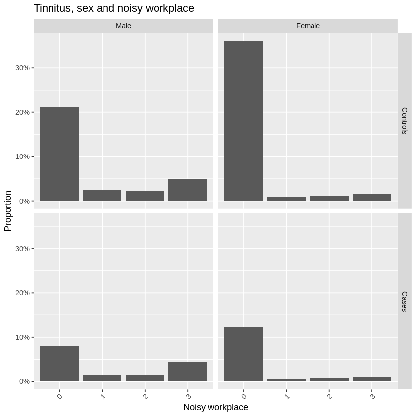

```python
label_sex <- c("1" = "Female", "0" = "Male")
label_tin <- c("1" = "Cases", "0" = "Controls")
sex.tin.noise <- ggplot(tinnitus_complete, aes(x = noise_wp)) +
  geom_bar(aes(y = (..count..)/sum(..count..))) +
  labs(title = "Tinnitus, sex and noisy workplace",
       x = "Noisy workplace",
       y = "Proportion of individuals") +
  scale_y_continuous(labels = scales::percent, name = "Proportion") +
  facet_grid(tinnitus ~ sex, labeller=labeller(sex = label_sex, tinnitus = label_tin)) +
  theme(axis.text.x = element_text(angle = 45, hjust = 1))
sex.tin.noise
```

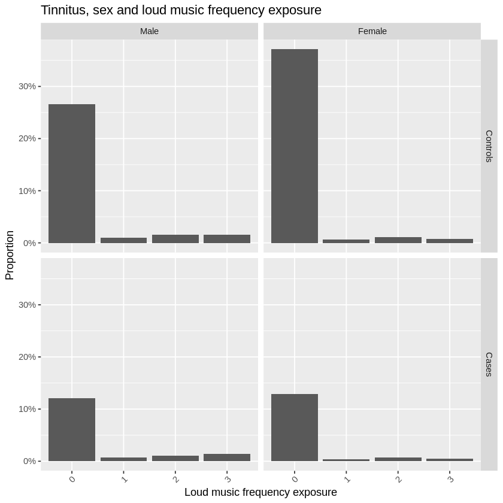

```python
sex.tin.music <- ggplot(tinnitus_complete, aes(x = loud_music)) +
  geom_bar(aes(y = (..count..)/sum(..count..))) +
    labs(title = "Tinnitus, sex and loud music frequency exposure",
       x = "Loud music frequency exposure",
       y = "Proportion of individuals") +
  scale_y_continuous(labels = scales::percent, name = "Proportion") +
  facet_grid(tinnitus ~ sex, labeller=labeller(sex = label_sex, tinnitus = label_tin)) +
  theme(axis.text.x = element_text(angle = 45, hjust = 1))
sex.tin.music
```

```python
summary_noise_age <- ddply(tinnitus_complete, c("noise_wp"), summarise,
               N    = length(age),
               mean = mean(age),
               sd   = sd(age))
summary_noise_age
```

A data.frame: 4 × 4

| noise_wp <fct> | N <int> | mean <dbl> | sd <dbl> |
| --- | --- | --- | --- |
| 0 | 106947 | 59.21024 | 8.476914 |
| 1 | 6969 | 57.96456 | 8.493229 |
| 2 | 7511 | 58.61377 | 8.577496 |
| 3 | 16418 | 60.26830 | 8.091813 |

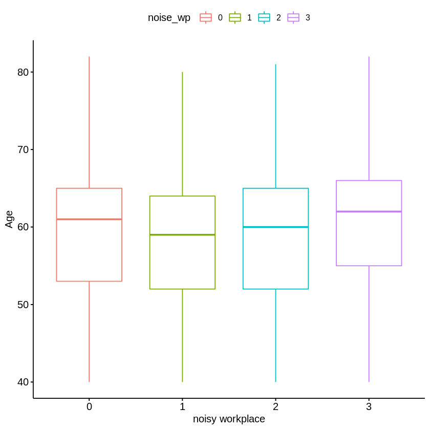

```python
noise.boxp <- ggboxplot(tinnitus_complete, x = "noise_wp", y = "age",
          color = "noise_wp",
          order = c("0", "1", "2", "3"),
          ylab = "Age", xlab = "noisy workplace")
noise.boxp
```

```python
res1.aov <- aov(age ~ noise_wp, data = tinnitus_complete)
summary(res1.aov)
TukeyHSD(res1.aov)
```

```
                Df  Sum Sq Mean Sq F value Pr(>F)
noise_wp         3   31738   10579   148.6 <2e-16 ***
Residuals   137841 9815050      71
---
Signif. codes:  0 ‘***’ 0.001 ‘**’ 0.01 ‘*’ 0.05 ‘.’ 0.1 ‘ ’ 1
```

```
  Tukey multiple comparisons of means
    95% family-wise confidence level

Fit: aov(formula = age ~ noise_wp, data = tinnitus_complete)

$noise_wp
          diff        lwr        upr    p adj
1-0 -1.2456870 -1.5136960 -0.9776780 0.00e+00
2-0 -0.5964779 -0.8552493 -0.3377064 0.00e+00
3-0  1.0580588  0.8763491  1.2397684 0.00e+00
2-1  0.6492092  0.2886499  1.0097684 2.22e-05
3-1  2.3037458  1.9938123  2.6136792 0.00e+00
3-2  1.6545366  1.3525555  1.9565177 0.00e+00
```

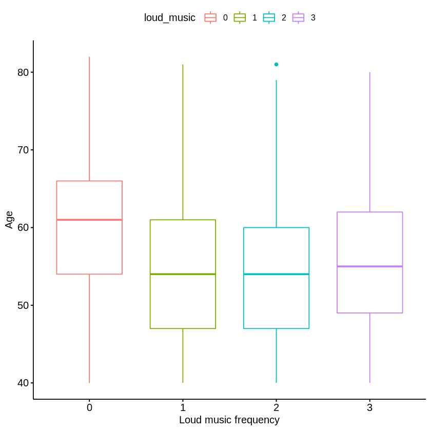

```python
music.boxp <- ggboxplot(tinnitus_complete, x = "loud_music", y = "age",
          color = "loud_music",
          order = c("0", "1", "2", "3"),
          ylab = "Age", xlab = "Loud music frequency")
music.boxp
```

```python
res2.aov <- aov(age ~ loud_music, data = tinnitus_complete)
summary(res2.aov)
TukeyHSD(res2.aov)
```

```
                Df  Sum Sq Mean Sq F value Pr(>F)
loud_music       3  379127  126376    1840 <2e-16 ***
Residuals   137841 9467660      69
---
Signif. codes:  0 ‘***’ 0.001 ‘**’ 0.01 ‘*’ 0.05 ‘.’ 0.1 ‘ ’ 1
```

```
  Tukey multiple comparisons of means
    95% family-wise confidence level

Fit: aov(formula = age ~ loud_music, data = tinnitus_complete)

$loud_music
          diff        lwr         upr     p adj
1-0 -5.3610351 -5.7105052 -5.01156499 0.0000000
2-0 -5.8124579 -6.0933446 -5.53157132 0.0000000
3-0 -4.4437925 -4.7317466 -4.15583837 0.0000000
2-1 -0.4514228 -0.8914357 -0.01140998 0.0417906
3-1  0.9172426  0.4726849  1.36180037 0.0000007
3-2  1.3686655  0.9757284  1.76160250 0.0000000
```

Correlation between the two noise variables for cases and controls separately using Kendall correlation

```python
cases <- tinnitus_complete %>%
  filter(tinnitus=="1")
noise_wp <- as.numeric(factor(cases$noise_wp,levels=c("0", "1", "2", "3")))
loud_music <- as.numeric(factor(cases$loud_music, levels=c("0", "1", "2", "3")))
m <- cbind(noise_wp, loud_music)
cor(m, method="kendall", use="pairwise")
cor.test(noise_wp, loud_music, method="kendall")
```

A matrix: 2 × 2 of type dbl

|  | noise_wp | loud_music |
| --- | --- | --- |
| noise_wp | 1.0000000 | 0.1353252 |
| loud_music | 0.1353252 | 1.0000000 |

```
	Kendall's rank correlation tau

data:  noise_wp and loud_music
z = 29.472, p-value < 2.2e-16
alternative hypothesis: true tau is not equal to 0
sample estimates:
      tau
0.1353252
```

```python
controls <- tinnitus_complete %>%
  filter(tinnitus=="0")
noise_wp.ctr <- as.numeric(factor(controls$noise_wp,levels=c("0", "1", "2", "3")))
loud_music.ctr <- as.numeric(factor(controls$loud_music, levels=c("0", "1", "2", "3")))
m1 <- cbind(noise_wp.ctr, loud_music.ctr)
cor(m1, method="kendall", use="pairwise")
cor.test(noise_wp.ctr, loud_music.ctr, method="kendall")
```

A matrix: 2 × 2 of type dbl

|  | noise_wp.ctr | loud_music.ctr |
| --- | --- | --- |
| noise_wp.ctr | 1.0000000 | 0.1456364 |
| loud_music.ctr | 0.1456364 | 1.0000000 |

```
	Kendall's rank correlation tau

data:  noise_wp.ctr and loud_music.ctr
z = 47.272, p-value < 2.2e-16
alternative hypothesis: true tau is not equal to 0
sample estimates:
      tau
0.1456364
```

Heat map for variable correlation

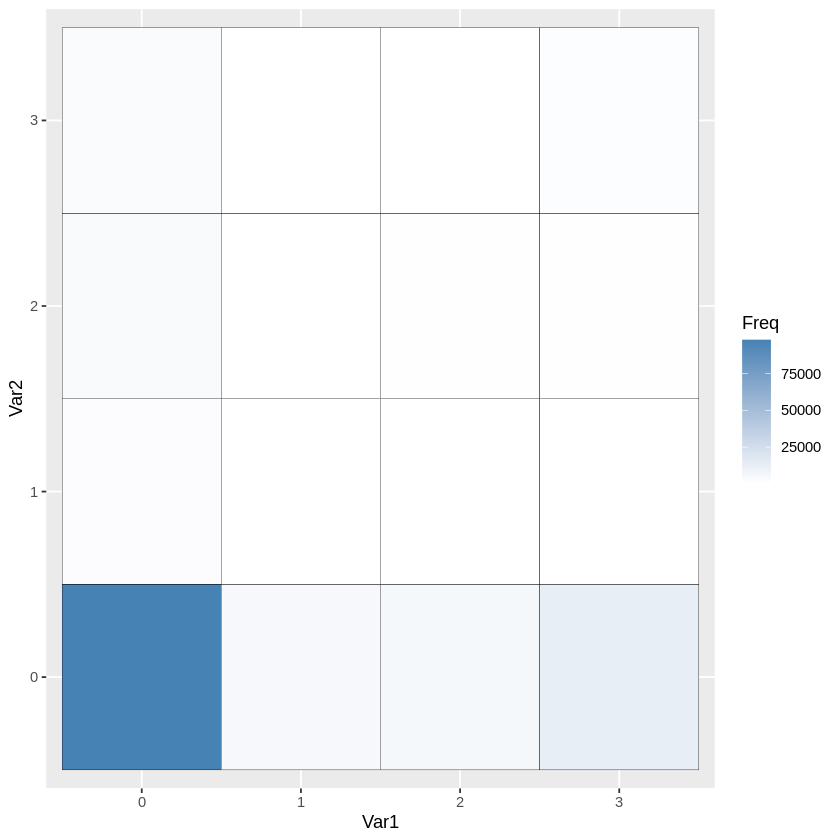

```python
#Heat map
noisevar.df <- as.data.frame(table(tinnitus_complete$noise_wp, tinnitus_complete$loud_music))
ggplot(noisevar.df, aes(Var1, Var2)) +
  geom_tile(aes(fill = Freq), colour = "black") +
  scale_fill_gradient(low = "white", high = "steelblue")
```

Fluctuation plot

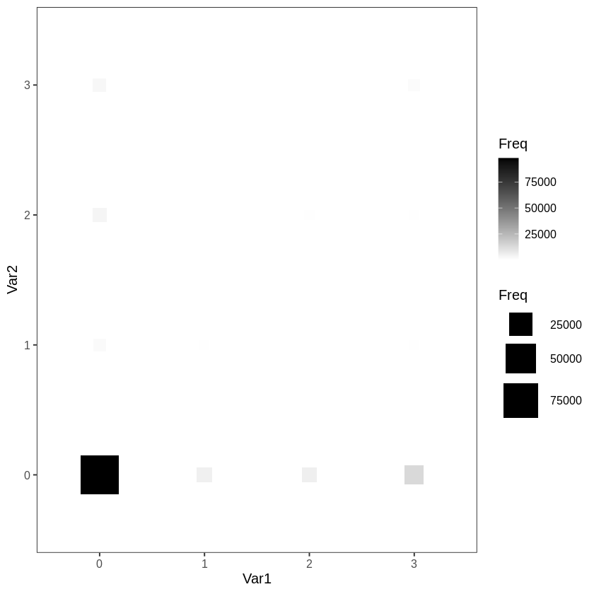

```python
# Fluctuation plot
theme_nogrid <- function (base_size = 12, base_family = "") {
  theme_bw(base_size = base_size, base_family = base_family) %+replace%
    theme(panel.grid = element_blank())
}
ggplot(noisevar.df, aes(Var1, Var2)) +
  geom_point(aes(size = Freq, color = Freq, stat = "identity", position = "identity"), shape = 15) +
  scale_size_continuous(range = c(3,15)) +
  scale_color_gradient(low = "white", high = "black") +
  theme_nogrid()
```

© 2020 Diana Cornejo at Center for Statistical Genetics, Sergievsky Center, Columbia University VP&S

Exported from [`analysis/phenotypes/Tinnitus_phenotype.ipynb`](http://github.com/dianacornejo/pleiotropy_UKB/blob/804a49e20903d8a6a7eafcb7472453c5ea2dcde8/analysis/phenotypes/Tinnitus_phenotype.ipynb) committed by dc2325 on Fri Feb 19 22:22:36 2021 [revision 1, 804a49e](http://github.com/dianacornejo/pleiotropy_UKB/commit/804a49e20903d8a6a7eafcb7472453c5ea2dcde8)